# Performance and Salary Prediction for NBA Players

MD SHABREZ 20BCE1690

2023-01-01

# 1. Data Preparation

Loading packages

```r
library(corrplot)
library(tidyverse)
library(ggplot2)
library(tidyr)
library(stringr)
library(GGally)
library(dplyr)
library(plotly)
```

Importing datasets

```r
sal=read.csv('nbaSalaryStats.csv',header=T)
```

We will take a look at the Salary Dataset first

```r
str(sal)
```

```
## 'data.frame':    705 obs. of  30 variables:
##  $ Player: chr  "Precious Achiuwa" "Jaylen Adams" "Steven Adams" "Bam Adebayo" ...
##  $ Pos   : chr  "PF" "PG" "C" "C" ...
##  $ Salary: chr  "2711280" "#N/A" "17073171" "28103550" ...
##  $ Age   : int  21 24 27 23 35 35 35 22 22 25 ...
##  $ Tm    : chr  "MIA" "MIL" "NOP" "MIA" ...
##  $ G     : int  61 7 58 64 26 21 5 15 46 50 ...
##  $ GS    : int  4 0 58 64 23 18 5 0 13 38 ...
##  $ MP    : num  12.1 2.6 27.7 33.5 25.9 25.9 26 3.1 21.9 25.2 ...
##  $ FG    : num  2 0.1 3.3 7.1 5.4 5.5 5 0.2 4.2 3.5 ...
##  $ FGA   : num  3.7 1.1 5.3 12.5 11.4 11.8 9.6 0.8 10 8.3 ...
##  $ FG.   : num  0.544 0.125 0.614 0.57 0.473 0.464 0.521 0.25 0.419 0.418 ...
##  $ X3P   : num  0 0 0 0 1.2 1.3 0.8 0.1 1.7 2.1 ...
##  $ X3PA  : num  0 0.3 0.1 0.1 3.1 3.6 1 0.6 4.8 5.5 ...
##  $ X3P.  : num  0 0 0 0.25 0.388 0.36 0.8 0.222 0.347 0.391 ...
```

[output cut: 16 more lines]

Removing duplicates

```r
sal <- sal %>%
  group_by(Player) %>%
  filter(G == max(G)) %>%
  distinct

sal$Salary=as.numeric(sal$Salary)
head(sal, 5)
```

```
## # A tibble: 5 × 30
## # Groups:   Player [5]
##   Player     Pos    Salary   Age Tm        G    GS    MP    FG   FGA   FG.   X3P
##   <chr>      <chr>   <dbl> <int> <chr> <int> <int> <dbl> <dbl> <dbl> <dbl> <dbl>
## 1 Precious … PF     2.71e6    21 MIA      61     4  12.1   2     3.7 0.544   0
## 2 Jaylen Ad… PG    NA         24 MIL       7     0   2.6   0.1   1.1 0.125   0
## 3 Steven Ad… C      1.71e7    27 NOP      58    58  27.7   3.3   5.3 0.614   0
## 4 Bam Adeba… C      2.81e7    23 MIA      64    64  33.5   7.1  12.5 0.57    0
## 5 LaMarcus … C      2.64e6    35 TOT      26    23  25.9   5.4  11.4 0.473   1.2
## # … with 18 more variables: X3PA <dbl>, X3P. <dbl>, X2P <dbl>, X2PA <dbl>,
## #   X2P. <dbl>, eFG. <dbl>, FT <dbl>, FTA <dbl>, FT. <dbl>, ORB <dbl>,
## #   DRB <dbl>, TRB <dbl>, AST <dbl>, STL <dbl>, BLK <dbl>, TOV <dbl>, PF <dbl>,
## #   PTS <dbl>
```

We will look remove all the records with salary= NA

```r
sal<- sal %>% drop_na(Salary)
```

Checking for NA’s

```r
sum(!complete.cases(sal))
```

```
## [1] 12
```

Seeing which columns have NA values

```r
summary(sal)
```

```
##     Player              Pos                Salary              Age
##  Length:415         Length:415         Min.   :       0   Min.   :19.00
##  Class :character   Class :character   1st Qu.: 2016580   1st Qu.:22.00
##  Mode  :character   Mode  :character   Median : 4629630   Median :25.00
##                                        Mean   : 8967505   Mean   :25.68
##                                        3rd Qu.:12316754   3rd Qu.:28.00
##                                        Max.   :45780966   Max.   :40.00
##
##       Tm                  G               GS              MP
##  Length:415         Min.   : 1.00   Min.   : 0.00   Min.   : 2.00
##  Class :character   1st Qu.:39.00   1st Qu.: 3.50   1st Qu.:16.60
##  Mode  :character   Median :52.00   Median :16.00   Median :22.90
##                     Mean   :49.22   Mean   :25.15   Mean   :22.42
##                     3rd Qu.:63.00   3rd Qu.:45.00   3rd Qu.:29.55
##                     Max.   :72.00   Max.   :72.00   Max.   :37.60
##
##        FG              FGA              FG.              X3P
##  Min.   : 0.000   Min.   : 0.500   Min.   :0.0000   Min.   :0.000
##  1st Qu.: 2.150   1st Qu.: 4.500   1st Qu.:0.4190   1st Qu.:0.400
##  Median : 3.300   Median : 7.300   Median :0.4500   Median :1.000
##  Mean   : 3.859   Mean   : 8.288   Mean   :0.4647   Mean   :1.172
##  3rd Qu.: 5.150   3rd Qu.:10.950   3rd Qu.:0.5000   3rd Qu.:1.800
##  Max.   :11.200   Max.   :23.000   Max.   :1.0000   Max.   :5.300
##
##       X3PA             X3P.             X2P              X2PA
##  Min.   : 0.000   Min.   :0.0000   Min.   : 0.000   Min.   : 0.10
##  1st Qu.: 1.400   1st Qu.:0.2955   1st Qu.: 1.250   1st Qu.: 2.40
##  Median : 2.800   Median :0.3480   Median : 2.200   Median : 4.20
##  Mean   : 3.223   Mean   :0.3271   Mean   : 2.688   Mean   : 5.07
##  3rd Qu.: 4.900   3rd Qu.:0.3910   3rd Qu.: 3.650   3rd Qu.: 6.70
##  Max.   :12.700   Max.   :1.0000   Max.   :10.200   Max.   :16.80
##                   NA's   :9
##       X2P.             eFG.              FT             FTA
##  Min.   :0.0000   Min.   :0.0000   Min.   :0.000   Min.   : 0.000
##  1st Qu.:0.4760   1st Qu.:0.4990   1st Qu.:0.700   1st Qu.: 0.850
##  Median :0.5210   Median :0.5330   Median :1.100   Median : 1.600
##  Mean   :0.5257   Mean   :0.5338   Mean   :1.599   Mean   : 2.058
##  3rd Qu.:0.5780   3rd Qu.:0.5700   3rd Qu.:2.050   3rd Qu.: 2.600
##  Max.   :1.0000   Max.   :1.0000   Max.   :9.200   Max.   :10.700
##
```

[output cut: 9 more lines]

```
##  Min.   : 0.00   Min.   :0.0000   Min.   :0.0000   Min.   :0.000
##  1st Qu.: 0.95   1st Qu.:0.4000   1st Qu.:0.2000   1st Qu.:0.700
##  Median : 1.70   Median :0.7000   Median :0.3000   Median :1.000
##  Mean   : 2.31   Mean   :0.7094   Mean   :0.4667   Mean   :1.242
##  3rd Qu.: 3.15   3rd Qu.:0.9000   3rd Qu.:0.6000   3rd Qu.:1.600
##  Max.   :11.70   Max.   :2.1000   Max.   :3.4000   Max.   :4.800
##
##        PF             PTS
##  Min.   :0.000   Min.   : 0.10
##  1st Qu.:1.400   1st Qu.: 5.55
##  Median :1.800   Median : 9.00
##  Mean   :1.804   Mean   :10.49
##  3rd Qu.:2.300   3rd Qu.:13.65
##  Max.   :4.000   Max.   :32.00
##
```

Removing Null values

```r
sal <- sal[complete.cases(sal), ]

summary(sal)
```

```
##     Player              Pos                Salary              Age
##  Length:403         Length:403         Min.   :       0   Min.   :19.00
##  Class :character   Class :character   1st Qu.: 2076364   1st Qu.:22.00
##  Mode  :character   Mode  :character   Median : 4692840   Median :25.00
##                                        Mean   : 9133037   Mean   :25.69
##                                        3rd Qu.:12566475   3rd Qu.:28.50
##                                        Max.   :45780966   Max.   :37.00
##       Tm                  G               GS              MP
##  Length:403         Min.   : 2.00   Min.   : 0.00   Min.   : 2.00
##  Class :character   1st Qu.:40.00   1st Qu.: 4.00   1st Qu.:16.95
##  Mode  :character   Median :53.00   Median :17.00   Median :23.00
##                     Mean   :49.83   Mean   :25.42   Mean   :22.66
##                     3rd Qu.:63.00   3rd Qu.:45.50   3rd Qu.:29.65
##                     Max.   :72.00   Max.   :72.00   Max.   :37.60
##        FG             FGA              FG.              X3P
##  Min.   : 0.00   Min.   : 0.500   Min.   :0.0000   Min.   :0.000
##  1st Qu.: 2.20   1st Qu.: 4.700   1st Qu.:0.4190   1st Qu.:0.500
##  Median : 3.40   Median : 7.500   Median :0.4500   Median :1.000
##  Mean   : 3.91   Mean   : 8.423   Mean   :0.4631   Mean   :1.205
##  3rd Qu.: 5.20   3rd Qu.:11.100   3rd Qu.:0.4975   3rd Qu.:1.800
##  Max.   :11.20   Max.   :23.000   Max.   :0.7690   Max.   :5.300
##       X3PA             X3P.             X2P              X2PA
##  Min.   : 0.000   Min.   :0.0000   Min.   : 0.000   Min.   : 0.200
##  1st Qu.: 1.500   1st Qu.:0.2985   1st Qu.: 1.300   1st Qu.: 2.500
##  Median : 2.900   Median :0.3480   Median : 2.200   Median : 4.300
##  Mean   : 3.309   Mean   :0.3277   Mean   : 2.707   Mean   : 5.118
##  3rd Qu.: 4.900   3rd Qu.:0.3910   3rd Qu.: 3.650   3rd Qu.: 6.700
##  Max.   :12.700   Max.   :1.0000   Max.   :10.200   Max.   :16.800
##       X2P.             eFG.              FT             FTA
##  Min.   :0.0000   Min.   :0.0000   Min.   :0.100   Min.   : 0.100
##  1st Qu.:0.4765   1st Qu.:0.4995   1st Qu.:0.700   1st Qu.: 0.900
##  Median :0.5190   Median :0.5330   Median :1.200   Median : 1.600
##  Mean   :0.5246   Mean   :0.5337   Mean   :1.627   Mean   : 2.085
##  3rd Qu.:0.5745   3rd Qu.:0.5690   3rd Qu.:2.100   3rd Qu.: 2.650
##  Max.   :0.8970   Max.   :0.8460   Max.   :9.200   Max.   :10.700
##       FT.              ORB             DRB              TRB
##  Min.   :0.3330   Min.   :0.000   Min.   : 0.300   Min.   : 0.30
##  1st Qu.:0.7085   1st Qu.:0.400   1st Qu.: 2.000   1st Qu.: 2.45
##  Median :0.7830   Median :0.700   Median : 2.900   Median : 3.60
##  Mean   :0.7672   Mean   :0.897   Mean   : 3.235   Mean   : 4.13
##  3rd Qu.:0.8460   3rd Qu.:1.200   3rd Qu.: 4.100   3rd Qu.: 5.40
##  Max.   :1.0000   Max.   :4.100   Max.   :10.100   Max.   :13.50
##       AST              STL              BLK              TOV
##  Min.   : 0.100   Min.   :0.0000   Min.   :0.0000   Min.   :0.100
##  1st Qu.: 1.000   1st Qu.:0.4000   1st Qu.:0.2000   1st Qu.:0.700
##  Median : 1.700   Median :0.7000   Median :0.3000   Median :1.000
##  Mean   : 2.364   Mean   :0.7171   Mean   :0.4586   Mean   :1.262
##  3rd Qu.: 3.200   3rd Qu.:0.9000   3rd Qu.:0.6000   3rd Qu.:1.650
##  Max.   :11.700   Max.   :2.1000   Max.   :3.4000   Max.   :4.800
##        PF             PTS
##  Min.   :0.100   Min.   : 0.40
##  1st Qu.:1.400   1st Qu.: 5.70
##  Median :1.800   Median : 9.10
##  Mean   :1.813   Mean   :10.65
##  3rd Qu.:2.300   3rd Qu.:13.90
##  Max.   :4.000   Max.   :32.00
```

Removing columns that are of no use to us

```r
sal=subset(sal, select=-c(Tm,FGA,X2PA,X3PA,FTA,X2P,X3P,FT,FG,FGA))
```

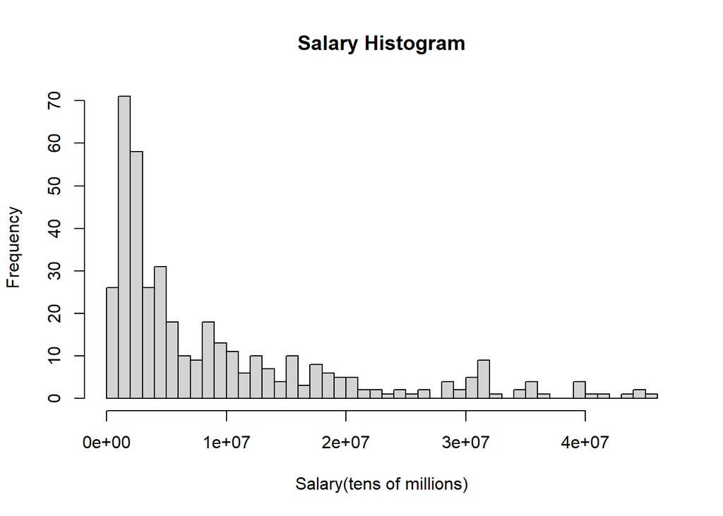

```r
hist(sal$Salary, breaks=50,
     main='Salary Histogram',
     xlab='Salary(tens of millions)',
     ylab='Frequency')
```

The NBA salaries follow a highly right-skewed distribution, which is reasonable considering that a few elite players earn significantly higher salaries than the average player. This is because there are only a handful of star players compared to the numerous players attempting to maintain their position in the league.

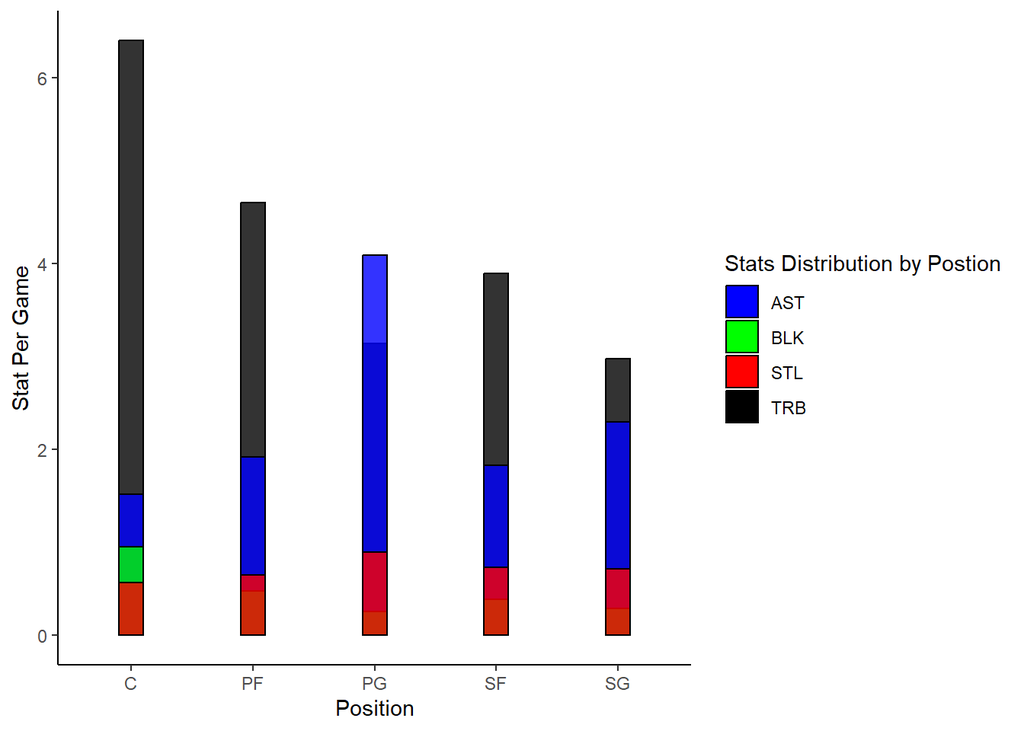

```r
library(dplyr)
library(ggplot2)

data = sal

dataPG <- data %>% filter(Pos == "PG")
dataSG <- data %>% filter(Pos == "SG")
dataSF <- data %>% filter(Pos == "SF")
dataPF <- data %>% filter(Pos == "PF")
dataC <- data %>% filter(Pos == "C")

avgTRB <- c(mean(dataPG$TRB), mean(dataSG$TRB), mean(dataSF$TRB), mean(dataPF$TRB), mean(dataC$TRB))
avgAST <- c(mean(dataPG$AST), mean(dataSG$AST), mean(dataSF$AST), mean(dataPF$AST), mean(dataC$AST))
avgBLK <- c(mean(dataPG$BLK), mean(dataSG$BLK), mean(dataSF$BLK), mean(dataPF$BLK), mean(dataC$BLK))
avgSTL <- c(mean(dataPG$STL), mean(dataSG$STL), mean(dataSF$STL), mean(dataPF$STL), mean(dataC$STL))

df <- data.frame(Position = c("PG", "SG", "SF", "PF", "C"),
                 TRB = avgTRB,
                 AST = avgAST,
                 BLK = avgBLK,
                 STL = avgSTL)

ggplot(df, aes(x = Position)) +
  geom_bar(aes(y = TRB, fill = "TRB"), stat = "identity", position = position_dodge(width = 0.6), width = 0.2, alpha = 0.8, color = "black") +
  geom_bar(aes(y = AST, fill = "AST"), stat = "identity", position = position_dodge(width = 0.6), width = 0.2, alpha = 0.8, color = "black") +
  geom_bar(aes(y = BLK, fill = "BLK"), stat = "identity", position = position_dodge(width = 0.6), width = 0.2, alpha = 0.8, color = "black") +
  geom_bar(aes(y = STL, fill = "STL"), stat = "identity", position = position_dodge(width = 0.6), width = 0.2, alpha = 0.8, color = "black") +
  labs(x = "Position", y = "Stat Per Game", fill = "Statistic") +
  scale_fill_manual(values = c("blue", "green", "red", "black")) +
  theme_classic() +
  guides(fill = guide_legend(title = "Stats Distribution by Postion"))
```

The bar chart displays the mean values of four statistics (rebounds, assists, blocks, and steals) for each position in basketball. It indicates that centers and power forwards excel in rebounds and blocks, while point guards and shooting guards perform better in assists and steals. As positions in basketball fulfill distinct roles for a team, these dissimilarities must be taken into consideration when determining salaries.

# 2. Correlation Check

```r
sal2=subset(sal, select=-c(Player,Pos))
correlation=cor(sal2[,colnames(sal2)!="Salary"],sal2$Salary)
correlation
```

```
##            [,1]
## Age  0.30768384
## G    0.22849581
## GS   0.60905164
## MP   0.67248061
## FG.  0.14577742
## X3P. 0.14268476
## X2P. 0.05881113
## eFG. 0.15355801
## FT.  0.24459778
## ORB  0.18823054
## DRB  0.57728391
## TRB  0.50139864
## AST  0.65219762
## STL  0.51065517
## BLK  0.25394040
## TOV  0.67521464
## PF   0.37131898
## PTS  0.77539564
```

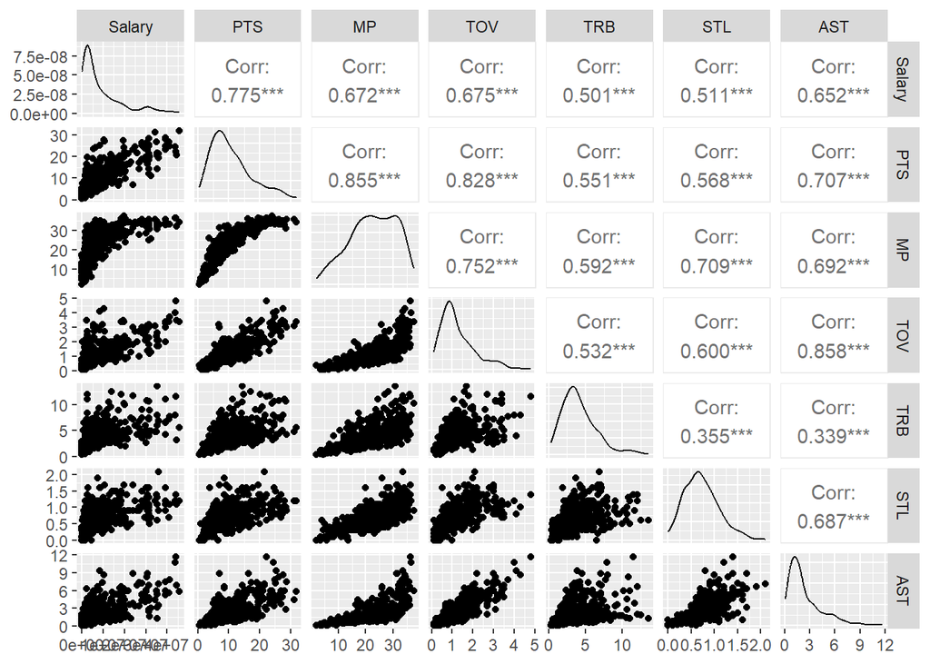

```r
stats=c("Salary", "PTS", "MP", "TOV", "TRB", "STL", "AST")
stats_salary_cor <-
  sal2 %>%
  select(Salary, PTS, MP, TOV, TRB, STL, AST)
ggpairs(stats_salary_cor)
```

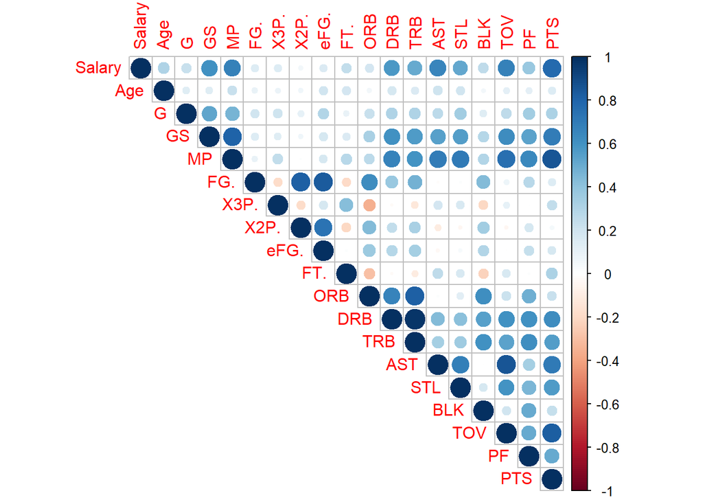

```r
corrplot(cor(sal2 %>% select(Salary, Age:PTS),use="complete.obs"),method = 'circle',type="upper")
```

Correlation Stats

```r
cor(stats_salary_cor)[,"Salary"]
```

```
##    Salary       PTS        MP       TOV       TRB       STL       AST
## 1.0000000 0.7753956 0.6724806 0.6752146 0.5013986 0.5106552 0.6521976
```

As we can see, the correlation strength is: PTS>TOV>MP>AST>STL>TRB

# 3. Data Visualization

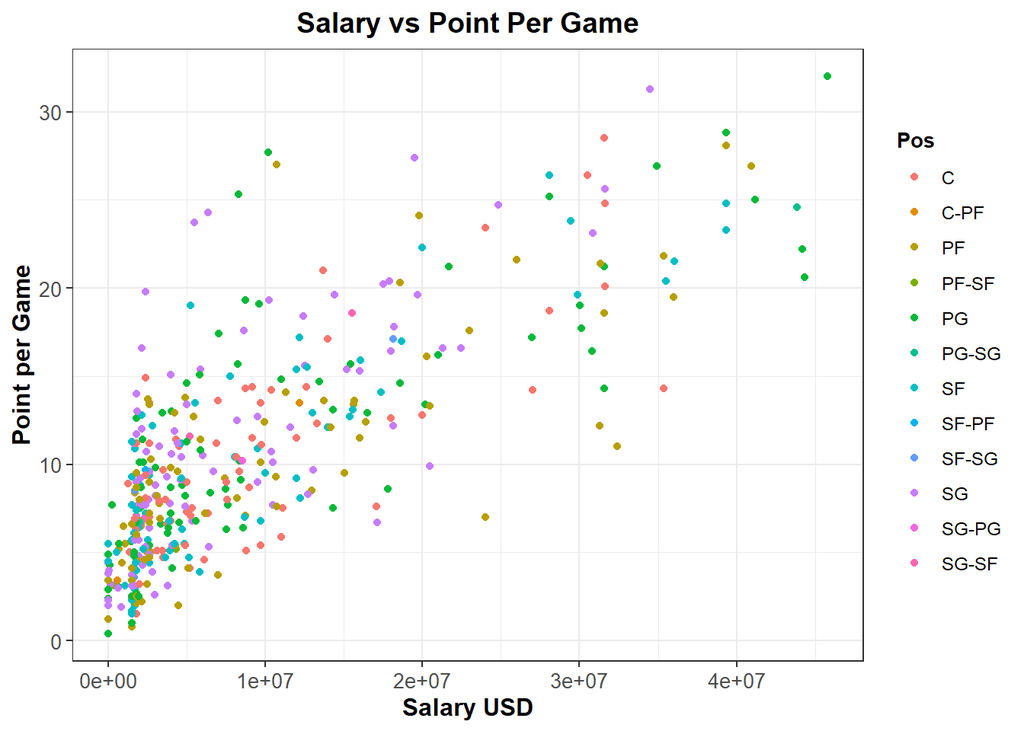

```r
text <- paste("Player: ", sal$Player,
              "<br>Salary: ", format(sal$Salary, big.mark = ","),"$",
              "<br>PTS: ", round(sal$PTS, digits = 3),
              "<br>POS: ", sal$Pos)

# Create a ggplot2 plot
ggplot(data = sal, aes(x = Salary, y = PTS, color = Pos, text = text)) +
  geom_point() +
  ggtitle("Salary vs Point Per Game") +
  xlab("Salary USD") +
  ylab("Point per Game") +
  theme_bw() +
  theme(plot.title = element_text(size = 14, face = "bold", hjust = 0.5),
        axis.title = element_text(size = 12, face = "bold"),
        axis.text = element_text(size = 10),
        legend.title = element_text(size = 10, face = "bold"),
        legend.text = element_text(size = 9))
```

# 4. Simple Linear Regression Model

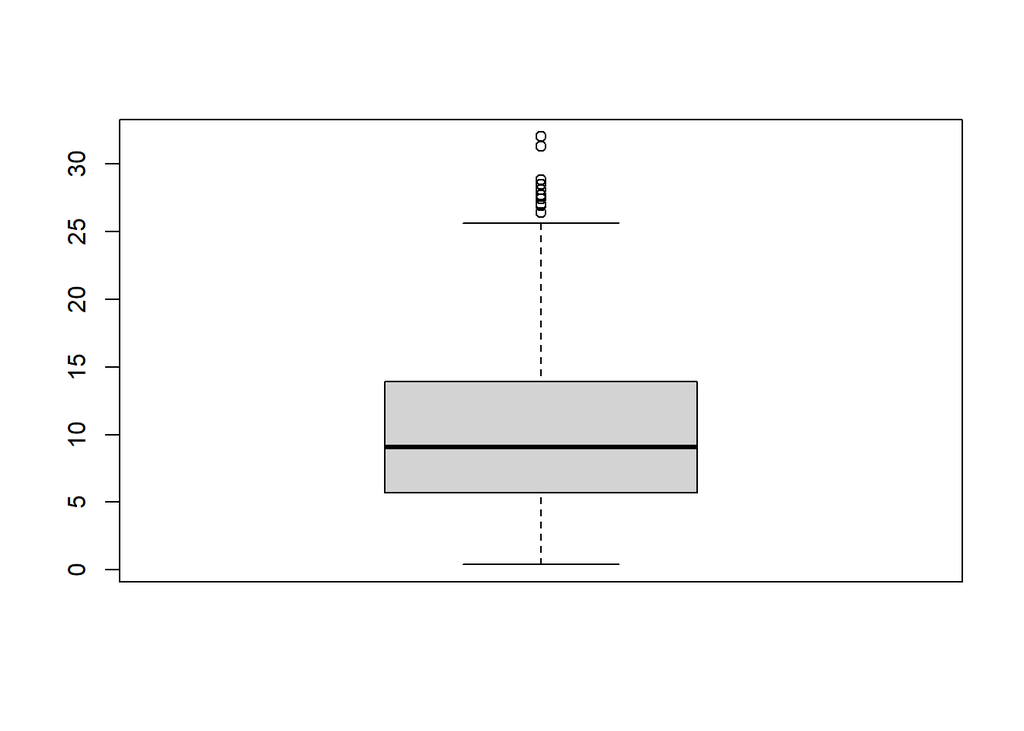

```r
#removing outliers of points
boxplot(sal$PTS)
```

```r
outliers_pts=boxplot(sal$PTS,plot=FALSE)$out
outliers_pts
```

```
##  [1] 28.1 31.3 32.0 27.7 26.9 28.5 26.9 26.4 27.4 28.8 26.4 26.4 27.0
```

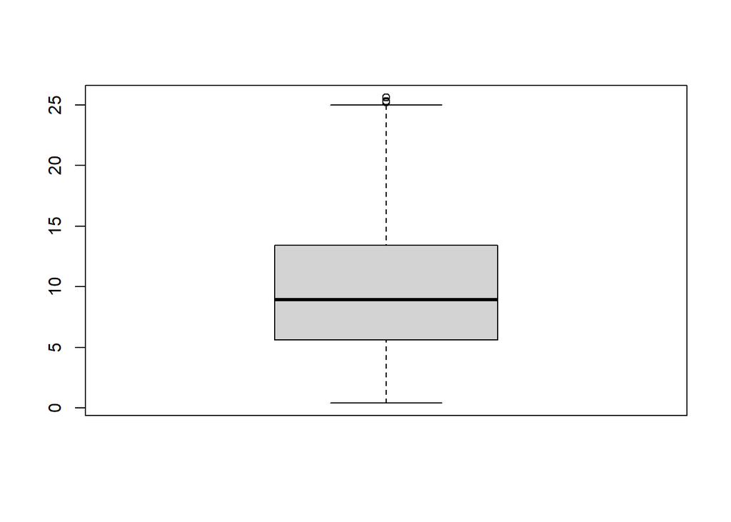

```r
sal_pts=sal %>% filter(!(PTS %in% outliers_pts))
boxplot(sal_pts$PTS)
```

Linear Regression

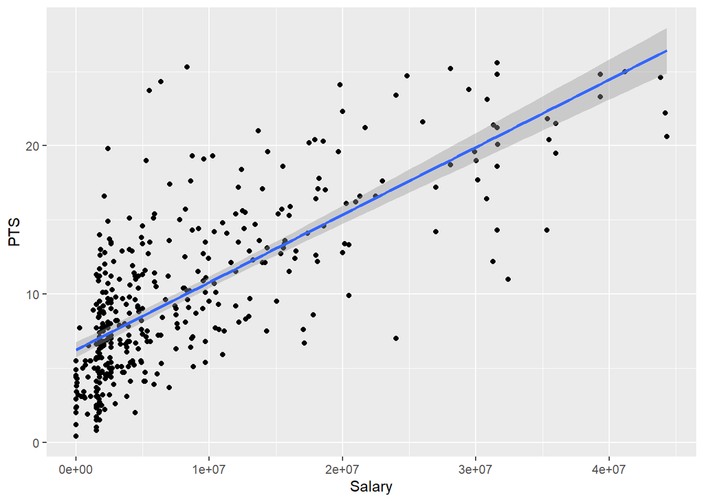

```r
sal_pts %>% ggplot(aes(x=Salary,y=PTS))+geom_point()+geom_smooth(method='lm')
```

Regression Analysis

```r
set.seed(44)
rel=lm(sal_pts$Salary~sal_pts$PTS)
summary(rel)
```

```
##
## Call:
## lm(formula = sal_pts$Salary ~ sal_pts$PTS)
##
## Residuals:
##       Min        1Q    Median        3Q       Max
## -19400298  -3212173   -169995   2458543  23161537
##
## Coefficients:
##             Estimate Std. Error t value Pr(>|t|)
## (Intercept) -3746974     641869  -5.838 1.12e-08 ***
## sal_pts$PTS  1208557      55452  21.795  < 2e-16 ***
## ---
## Signif. codes:  0 '***' 0.001 '**' 0.01 '*' 0.05 '.' 0.1 ' ' 1
##
## Residual standard error: 6242000 on 388 degrees of freedom
## Multiple R-squared:  0.5504, Adjusted R-squared:  0.5493
## F-statistic:   475 on 1 and 388 DF,  p-value: < 2.2e-16
```

Prediction

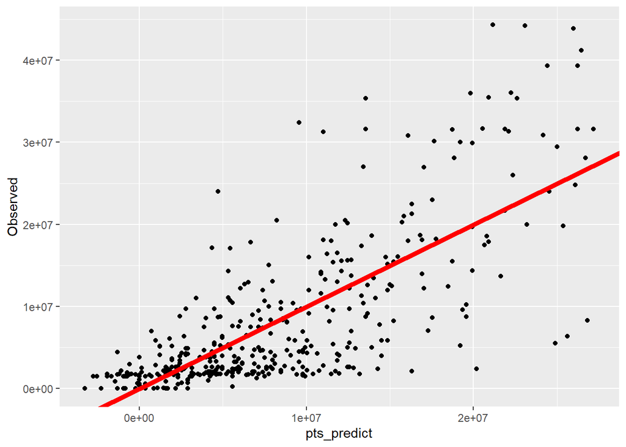

```r
pts_predict=predict(rel,sal_pts)
data_pts=data.frame(Predicted=pts_predict,Observed=sal_pts$Salary)
ggplot(data_pts,aes(x=pts_predict,y=Observed))+geom_point()+geom_abline(intercept=0,slope=1,color="red",size=2)
```

# 5. Multiple Linear Regression

outliers

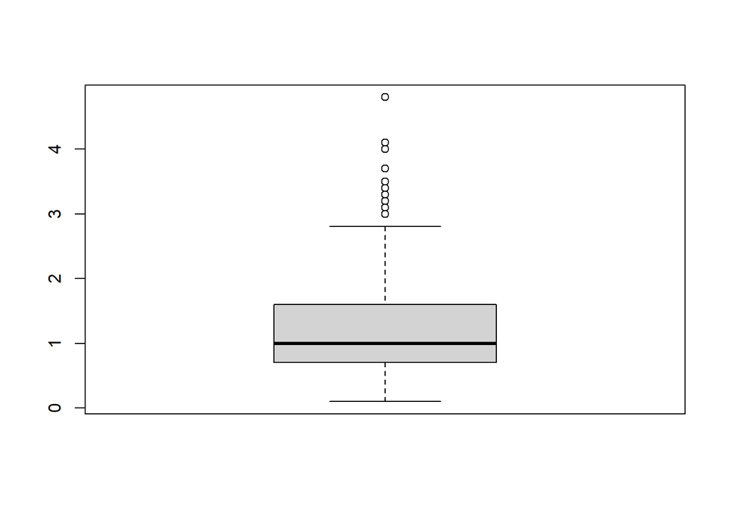

```r
boxplot(sal_pts$TOV)
```

```r
outliers_mult=boxplot(sal_pts$TOV,plot=FALSE)$out
outliers_mult
```

```
##  [1] 3.1 3.0 3.0 3.3 3.0 3.0 4.0 3.2 3.7 3.2 3.5 3.4 3.4 3.0 3.2 3.5 4.8 4.1
```

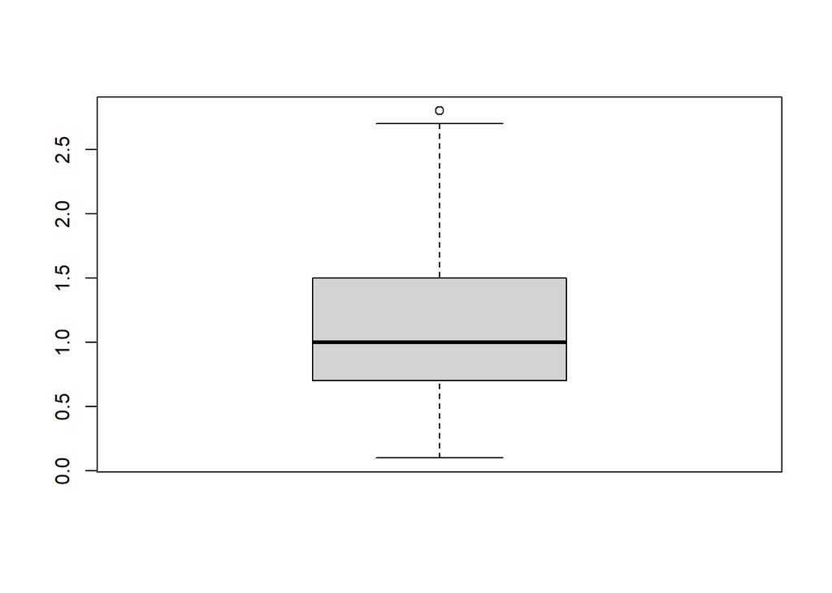

```r
sal_mult=sal_pts %>% filter(!(TOV %in% outliers_mult))
boxplot(sal_mult$TOV)
```

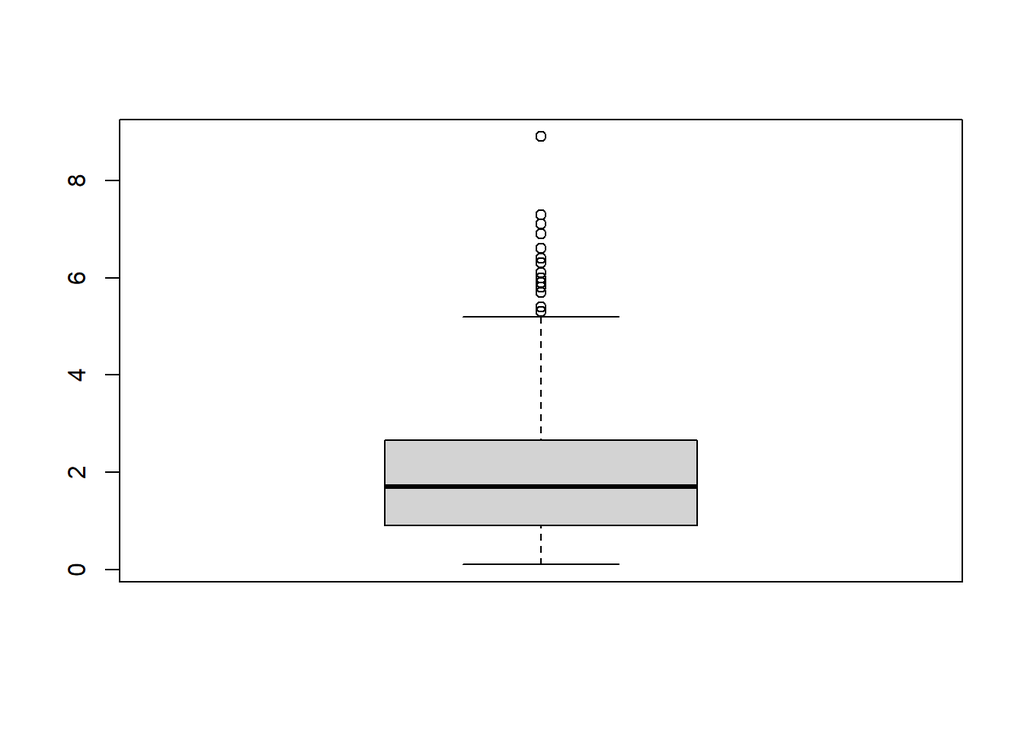

```r
boxplot(sal_mult$AST)
```

```r
outliers_mult=boxplot(sal_mult$AST,plot=FALSE)$out
outliers_mult
```

```
##  [1] 5.4 6.1 5.7 5.9 7.1 6.0 6.9 5.4 5.4 5.3 6.1 7.3 6.6 5.4 5.4 8.9 6.4 5.8 5.8
## [20] 5.7 6.3
```

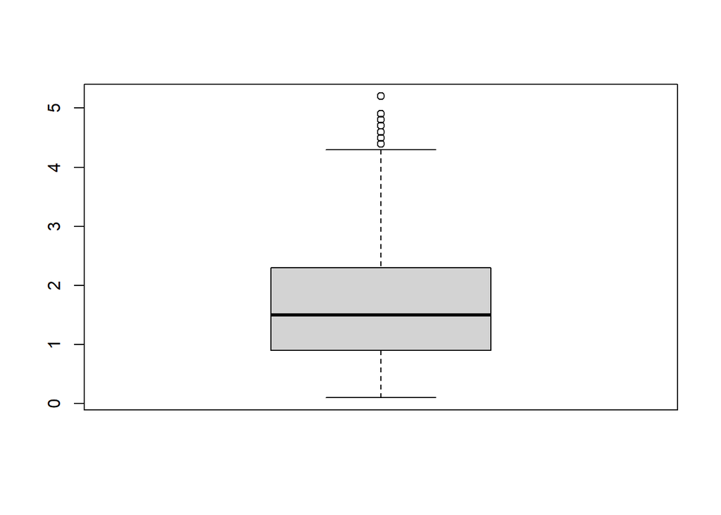

```r
sal_mult=sal_mult %>% filter(!(AST %in% outliers_mult))
boxplot(sal_mult$AST)
```

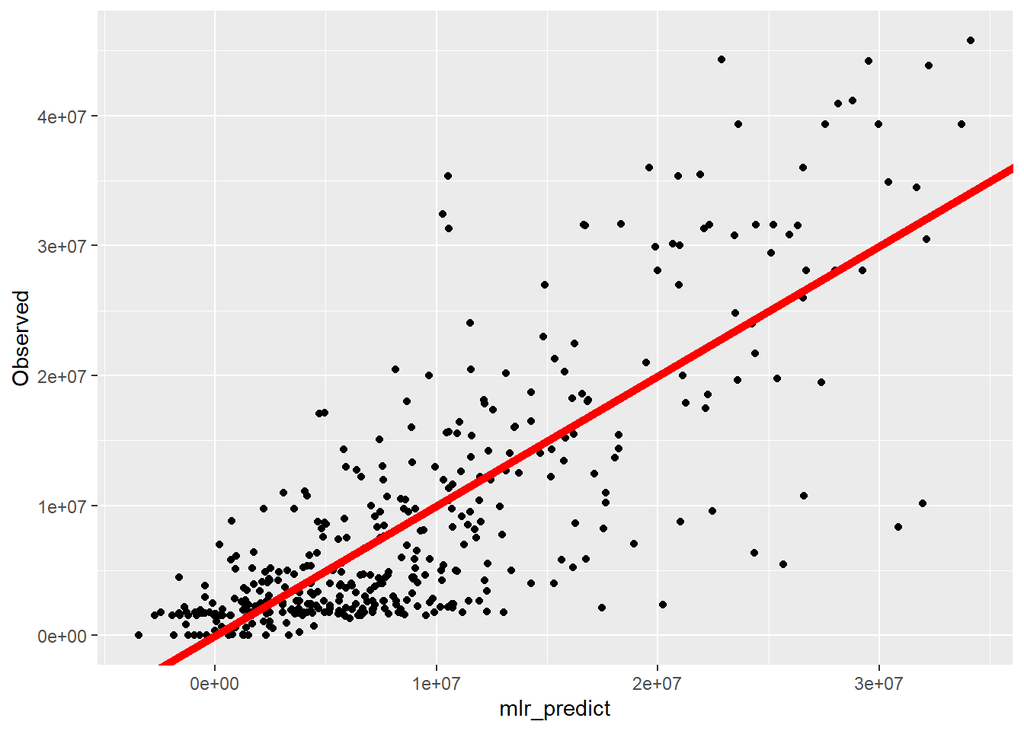

```r
set.seed(44)
mult=lm(sal$Salary~sal$PTS+sal$TOV+sal$MP+sal$AST)
mlr_predict=predict(mult,sal)
data_mlr=data.frame(Predicted=mlr_predict,Observed=sal$Salary)
ggplot(data_mlr,aes(x=mlr_predict,y=Observed))+geom_point()+geom_abline(intercept=0,slope=1,color="red",size=2)
```

```r
summary(mult)
```

```
##
## Call:
## lm(formula = sal$Salary ~ sal$PTS + sal$TOV + sal$MP + sal$AST)
##
## Residuals:
##       Min        1Q    Median        3Q       Max
## -22532051  -3425800   -180373   2674002  24829258
##
## Coefficients:
##             Estimate Std. Error t value Pr(>|t|)
## (Intercept) -3254392    1006011  -3.235  0.00132 **
## sal$PTS      1124804     110813  10.150  < 2e-16 ***
## sal$TOV     -1729405     906369  -1.908  0.05710 .
## sal$MP        -43516      73878  -0.589  0.55618
## sal$AST      1511961     313193   4.828 1.97e-06 ***
## ---
## Signif. codes:  0 '***' 0.001 '**' 0.01 '*' 0.05 '.' 0.1 ' ' 1
##
## Residual standard error: 6209000 on 398 degrees of freedom
## Multiple R-squared:  0.6267, Adjusted R-squared:  0.6229
## F-statistic:   167 on 4 and 398 DF,  p-value: < 2.2e-16
```

```r
sal_pred_mlr=predict(mult,sal_mult)
results2=cbind(sal_mult$Player,sal_pred_mlr,sal_mult$Salary)
colnames(results2)=c("Name","pred","real")
results.mult=as.data.frame(results2)
results.mult$pred=as.numeric(results.mult$pred)
results.mult$real=as.numeric(results.mult$real)
head(results.mult, 10)
```

```
##                        Name       pred     real
## 1          Precious Achiuwa  1388480.7  2711280
## 2              Steven Adams  4713224.5 17073171
## 3         LaMarcus Aldridge 19989786.8  2641691
## 4  Nickeil Alexander-Walker 11946715.0  3261480
## 5             Grayson Allen  8897655.3  4054695
## 6             Jarrett Allen  9168834.2 20000000
## 7             Kyle Anderson  9658308.7  9937150
## 8    Thanasis Antetokounmpo 12872961.1  1729217
## 9           Carmelo Anthony 29957153.5  2641691
## 10             Cole Anthony  -588520.8  3449400
```

# 6. Random Forest Regression

```r
library(randomForest)
set.seed(44)
#shuffle the dataset
sal=sal[sample(1:nrow(sal)),]

#random forest
samp=sample(nrow(sal),0.8*nrow(sal))
train=sal[samp,]
test=sal[-samp,]
salary.rf=randomForest(Salary ~ .,data=train,mtry=4,ntree = 2000, importance=TRUE,na.action=na.omit)
salary.rf
```

```
##
## Call:
##  randomForest(formula = Salary ~ ., data = train, mtry = 4, ntree = 2000,      importance = TRUE, na.action = na.omit)
##                Type of random forest: regression
##                      Number of trees: 2000
## No. of variables tried at each split: 4
##
##           Mean of squared residuals: 3.243694e+13
##                     % Var explained: 71.27
```

```r
sal_pred=predict(salary.rf,test)
results3=cbind(test$Player,sal_pred,test$Salary)
colnames(results3)=c("Name","pred","real")
results.rf=as.data.frame(results3)
results.rf$pred=as.numeric(results.rf$pred)
results.rf$real=as.numeric(results.rf$real)
head(results.rf, 10)
```

```
##               Name     pred     real
## 1      Amir Coffey  1472463   153488
## 2  Anthony Edwards 14386463 10245480
## 3    Derrick White 11931827 15178571
## 4     Gabriel Deck  4754053  1690507
## 5      Isaac Bonga  1980876  1729217
## 6  Justise Winslow  3829001  3902439
## 7     Jared Harper  1366490        0
## 8    Norman Powell 19415198 15517242
## 9      Buddy Hield 20866888 22477273
## 10    Kelly Olynyk 15036911 12195122
```

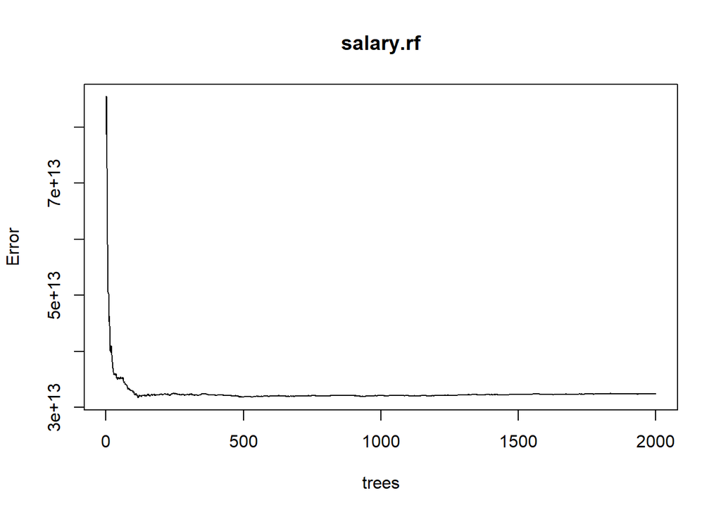

```r
plot(salary.rf)
```

# 7. Making Labeled Data for Salary Range

```r
# Define the salary range and corresponding labels
salary_range <- c(0, 15e6, 30e6, 46e6)
salary_labels <- c("L", "M", "H")

# Categorize the salaries into three categories
sal$Salary_Class <- cut(sal$Salary, breaks = salary_range, labels = salary_labels)

# View the updated dataframe
head(sal, 10)
```

```
## # A tibble: 10 × 22
## # Groups:   Player [10]
##    Player     Pos   Salary   Age     G    GS    MP   FG.  X3P.  X2P.  eFG.   FT.
##    <chr>      <chr>  <dbl> <int> <int> <int> <dbl> <dbl> <dbl> <dbl> <dbl> <dbl>
##  1 Amir Coff… SG    1.53e5    23    44     1   9   0.437 0.411 0.468 0.549 0.711
##  2 Anthony E… SG    1.02e7    19    72    55  32.1 0.417 0.329 0.483 0.488 0.776
##  3 Thomas Br… C     8.73e6    23    10    10  27.1 0.648 0.429 0.714 0.698 0.667
##  4 Jaren Jac… C     9.18e6    21    11     4  23.5 0.424 0.283 0.554 0.492 0.833
##  5 Darius Ga… PG    7.04e6    21    54    50  33.1 0.451 0.395 0.479 0.517 0.848
##  6 R.J. Hamp… SG-PG 2.30e6    19    51     1  17.4 0.435 0.31  0.482 0.478 0.671
##  7 Kenrich W… PF    2   e6    26    66    13  21.6 0.533 0.444 0.568 0.596 0.571
##  8 Khris Mid… SF    3.55e7    29    68    68  33.4 0.476 0.414 0.508 0.546 0.898
##  9 Derrick W… SG    1.52e7    26    36    32  29.6 0.411 0.346 0.486 0.503 0.851
## 10 Giannis A… PF    3.93e7    26    61    61  33   0.569 0.303 0.636 0.6   0.685
## # … with 10 more variables: ORB <dbl>, DRB <dbl>, TRB <dbl>, AST <dbl>,
## #   STL <dbl>, BLK <dbl>, TOV <dbl>, PF <dbl>, PTS <dbl>, Salary_Class <fct>
```

# 8. K - Nearest Neighbour

```r
library(e1071)
library(caTools)
library(class)
library(caret)
set.seed(44)

# Select the relevant columns
sal_select <- sal[, c(4:22)]

sal_select = na.omit(sal_select)

data = sal_select

# Split the data into training and test sets
trainIndex <- createDataPartition(data$Salary_Class, p = 0.7, list = FALSE)
trainData <- data[trainIndex, ]
testData <- data[-trainIndex, ]

# Scale the features in the training and test sets
preproc <- preProcess(trainData[,1:18], method=c("center", "scale"))
trainData[,1:18] <- predict(preproc, trainData[,1:18])
testData[,1:18] <- predict(preproc, testData[,1:18])

# Train the KNN model
knnFit <- train(Salary_Class ~ ., data = trainData, method = "knn", tuneLength = 10,
                trControl = trainControl(method = "cv", number = 5))

# Use the trained model to make predictions on the test set
predictions <- predict(knnFit, testData)

# Evaluate the accuracy of the model
confusionMatrix(predictions, testData$Salary_Class)
```

```
## Confusion Matrix and Statistics
##
##           Reference
## Prediction  L  M  H
##          L 92  7  2
##          M  1  5  4
##          H  0  3  3
##
## Overall Statistics
##
##                Accuracy : 0.8547
##                  95% CI : (0.7776, 0.913)
##     No Information Rate : 0.7949
##     P-Value [Acc > NIR] : 0.06413
##
##                   Kappa : 0.5139
##
##  Mcnemar's Test P-Value : 0.08420
##
## Statistics by Class:
##
##                      Class: L Class: M Class: H
## Sensitivity            0.9892  0.33333  0.33333
## Specificity            0.6250  0.95098  0.97222
## Pos Pred Value         0.9109  0.50000  0.50000
## Neg Pred Value         0.9375  0.90654  0.94595
## Prevalence             0.7949  0.12821  0.07692
## Detection Rate         0.7863  0.04274  0.02564
## Detection Prevalence   0.8632  0.08547  0.05128
## Balanced Accuracy      0.8071  0.64216  0.65278
```

# 9. Random Forest

```r
library(e1071)
library(caTools)
library(class)
library(caret)
library(randomForest)

set.seed(44)

# Select the relevant columns
sal_select <- sal[, c(4:22)]

sal_select = na.omit(sal_select)

data = sal_select


# Split the data into training and test sets
trainIndex <- createDataPartition(data$Salary_Class, p = 0.7, list = FALSE)
trainData <- data[trainIndex, ]
testData <- data[-trainIndex, ]

# Train the Random Forest model
rfFit <- randomForest(Salary_Class ~ ., data = trainData, ntree= 500)

# Use the trained model to make predictions on the test set
predictions <- predict(rfFit, testData)

# Evaluate the accuracy of the model
confusionMatrix(predictions, testData$Salary_Class)
```

```
## Confusion Matrix and Statistics
##
##           Reference
## Prediction  L  M  H
##          L 92  5  2
##          M  1  6  4
##          H  0  4  3
##
## Overall Statistics
##
##                Accuracy : 0.8632
##                  95% CI : (0.7874, 0.9198)
##     No Information Rate : 0.7949
##     P-Value [Acc > NIR] : 0.03832
##
##                   Kappa : 0.5599
##
##  Mcnemar's Test P-Value : 0.19790
##
## Statistics by Class:
##
##                      Class: L Class: M Class: H
## Sensitivity            0.9892  0.40000  0.33333
## Specificity            0.7083  0.95098  0.96296
## Pos Pred Value         0.9293  0.54545  0.42857
## Neg Pred Value         0.9444  0.91509  0.94545
## Prevalence             0.7949  0.12821  0.07692
## Detection Rate         0.7863  0.05128  0.02564
## Detection Prevalence   0.8462  0.09402  0.05983
## Balanced Accuracy      0.8488  0.67549  0.64815
```

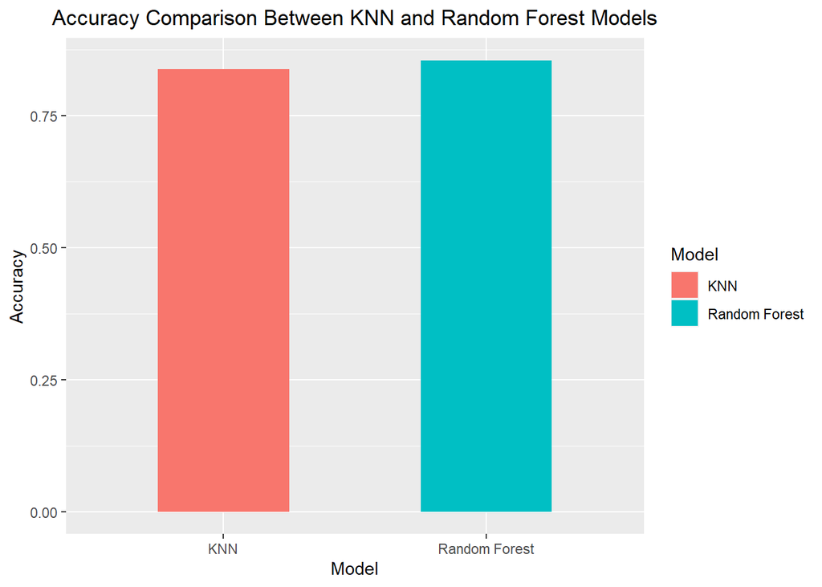

```r
library(e1071)
library(caTools)
library(class)
library(caret)
library(randomForest)
set.seed(44)
# Select the relevant columns
sal_select <- sal[, c(4:22)]

sal_select = na.omit(sal_select)

data = sal_select

# Split the data into training and test sets
trainIndex <- createDataPartition(data$Salary_Class, p = 0.7, list = FALSE)
trainData <- data[trainIndex, ]
testData <- data[-trainIndex, ]

# Scale the features in the training and test sets
preproc <- preProcess(trainData[,1:18], method=c("center", "scale"))
trainData[,1:18] <- predict(preproc, trainData[,1:18])
testData[,1:18] <- predict(preproc, testData[,1:18])

# Train the KNN model
knnFit <- train(Salary_Class ~ ., data = trainData, method = "knn", tuneLength = 10,
                trControl = trainControl(method = "cv", number = 10))

# Use the trained model to make predictions on the test set
knn_predictions <- predict(knnFit, testData)

# Evaluate the accuracy of the KNN model
knn_cm <- confusionMatrix(knn_predictions, testData$Salary_Class)
knn_accuracy <- knn_cm$overall["Accuracy"]

# Train the Random Forest model
rfFit <- randomForest(Salary_Class ~ ., data = trainData, ntree= 500)

# Use the trained model to make predictions on the test set
rf_predictions <- predict(rfFit, testData)

# Evaluate the accuracy of the Random Forest model
rf_cm <- confusionMatrix(rf_predictions, testData$Salary_Class)
rf_accuracy <- rf_cm$overall["Accuracy"]

# Create a data frame with the accuracy information
accuracy_df <- data.frame(Model = c("KNN", "Random Forest"),
                           Accuracy = c(knn_accuracy, rf_accuracy))

# Create a colorful bar graph with a legend of the accuracy comparison
library(ggplot2)

ggplot(accuracy_df, aes(x = Model, y = Accuracy, fill = Model)) +
  geom_bar(stat = "identity", width = 0.5) +
  scale_fill_manual(values = c("#F8766D", "#00BFC4")) +
  ggtitle("Accuracy Comparison Between KNN and Random Forest Models") +
  xlab("Model") +
  ylab("Accuracy") +
  theme(plot.title = element_text(hjust = 0.5))
```

# 10. Performance Analysis

Importing Dataset

```r
games_details=read.csv('games_details.csv',header=T)
games <- read.csv("games.csv")
teams = read.csv('teams.csv',header=T)
summary(games_details)
```

```
##     GAME_ID            TEAM_ID          TEAM_ABBREVIATION   TEAM_CITY
##  Min.   :10300001   Min.   :1.611e+09   Length:668628      Length:668628
##  1st Qu.:20700032   1st Qu.:1.611e+09   Class :character   Class :character
##  Median :21200962   Median :1.611e+09   Mode  :character   Mode  :character
##  Mean   :21717714   Mean   :1.611e+09
##  3rd Qu.:21800141   3rd Qu.:1.611e+09
##  Max.   :52100211   Max.   :1.611e+09
##
##    PLAYER_ID         PLAYER_NAME          NICKNAME         START_POSITION
##  Min.   :1.500e+01   Length:668628      Length:668628      Length:668628
##  1st Qu.:2.466e+03   Class :character   Class :character   Class :character
##  Median :2.012e+05   Mode  :character   Mode  :character   Mode  :character
##  Mean   :4.013e+05
##  3rd Qu.:2.035e+05
##  Max.   :1.963e+09
##
##    COMMENT              MIN                 FGM              FGA
##  Length:668628      Length:668628      Min.   : 0.00    Min.   : 0.0
##  Class :character   Class :character   1st Qu.: 1.00    1st Qu.: 3.0
##  Mode  :character   Mode  :character   Median : 3.00    Median : 7.0
##                                        Mean   : 3.59    Mean   : 7.9
##                                        3rd Qu.: 5.00    3rd Qu.:11.0
##                                        Max.   :28.00    Max.   :50.0
##                                        NA's   :109690   NA's   :109690
##      FG_PCT            FG3M             FG3A           FG3_PCT
##  Min.   :0.00     Min.   : 0.00    Min.   : 0.00    Min.   :0.0
##  1st Qu.:0.27     1st Qu.: 0.00    1st Qu.: 0.00    1st Qu.:0.0
##  Median :0.43     Median : 0.00    Median : 1.00    Median :0.0
##  Mean   :0.42     Mean   : 0.78    Mean   : 2.19    Mean   :0.2
##  3rd Qu.:0.57     3rd Qu.: 1.00    3rd Qu.: 4.00    3rd Qu.:0.4
##  Max.   :1.00     Max.   :14.00    Max.   :24.00    Max.   :1.0
##  NA's   :109690   NA's   :109690   NA's   :109690   NA's   :109690
##       FTM              FTA             FT_PCT            OREB
##  Min.   : 0.00    Min.   : 0.00    Min.   :0.00     Min.   : 0.00
##  1st Qu.: 0.00    1st Qu.: 0.00    1st Qu.:0.00     1st Qu.: 0.00
##  Median : 1.00    Median : 2.00    Median :0.50     Median : 1.00
##  Mean   : 1.73    Mean   : 2.28    Mean   :0.44     Mean   : 1.02
##  3rd Qu.: 3.00    3rd Qu.: 4.00    3rd Qu.:0.91     3rd Qu.: 2.00
##  Max.   :26.00    Max.   :39.00    Max.   :1.00     Max.   :18.00
##  NA's   :109690   NA's   :109690   NA's   :109690   NA's   :109690
```

[output cut: 9 more lines]

```
##  Min.   : 0.00    Min.   : 0.00    Min.   : 0       Min.   : 0.00
##  1st Qu.: 0.00    1st Qu.: 0.00    1st Qu.: 1       1st Qu.: 3.00
##  Median : 0.00    Median : 1.00    Median : 2       Median : 8.00
##  Mean   : 0.46    Mean   : 1.32    Mean   : 2       Mean   : 9.69
##  3rd Qu.: 1.00    3rd Qu.: 2.00    3rd Qu.: 3       3rd Qu.:14.00
##  Max.   :12.00    Max.   :12.00    Max.   :15       Max.   :81.00
##  NA's   :109690   NA's   :109690   NA's   :109690   NA's   :109690
##    PLUS_MINUS
##  Min.   :-57
##  1st Qu.: -7
##  Median :  0
##  Mean   :  0
##  3rd Qu.:  6
##  Max.   : 57
##  NA's   :133351
```

```r
summary(games)
```

```
##  GAME_DATE_EST         GAME_ID         GAME_STATUS_TEXT    HOME_TEAM_ID
##  Length:26651       Min.   :10300001   Length:26651       Min.   :1.611e+09
##  Class :character   1st Qu.:20700010   Class :character   1st Qu.:1.611e+09
##  Mode  :character   Median :21200763   Mode  :character   Median :1.611e+09
##                     Mean   :21754867                      Mean   :1.611e+09
##                     3rd Qu.:21800046                      3rd Qu.:1.611e+09
##                     Max.   :52100211                      Max.   :1.611e+09
##
##  VISITOR_TEAM_ID         SEASON      TEAM_ID_home          PTS_home
##  Min.   :1.611e+09   Min.   :2003   Min.   :1.611e+09   Min.   : 36.0
##  1st Qu.:1.611e+09   1st Qu.:2007   1st Qu.:1.611e+09   1st Qu.: 94.0
##  Median :1.611e+09   Median :2012   Median :1.611e+09   Median :103.0
##  Mean   :1.611e+09   Mean   :2012   Mean   :1.611e+09   Mean   :103.5
##  3rd Qu.:1.611e+09   3rd Qu.:2017   3rd Qu.:1.611e+09   3rd Qu.:112.0
##  Max.   :1.611e+09   Max.   :2022   Max.   :1.611e+09   Max.   :168.0
##                                                         NA's   :99
##   FG_PCT_home      FT_PCT_home      FG3_PCT_home      AST_home
##  Min.   :0.2500   Min.   :0.1430   Min.   :0.000   Min.   : 6.00
##  1st Qu.:0.4220   1st Qu.:0.6970   1st Qu.:0.286   1st Qu.:19.00
##  Median :0.4600   Median :0.7650   Median :0.357   Median :23.00
##  Mean   :0.4607   Mean   :0.7604   Mean   :0.356   Mean   :22.82
##  3rd Qu.:0.5000   3rd Qu.:0.8330   3rd Qu.:0.429   3rd Qu.:26.00
##  Max.   :0.6840   Max.   :1.0000   Max.   :1.000   Max.   :50.00
##  NA's   :99       NA's   :99       NA's   :99      NA's   :99
##     REB_home      TEAM_ID_away          PTS_away      FG_PCT_away
##  Min.   :15.00   Min.   :1.611e+09   Min.   : 33.0   Min.   :0.2440
##  1st Qu.:39.00   1st Qu.:1.611e+09   1st Qu.: 91.0   1st Qu.:0.4120
##  Median :43.00   Median :1.611e+09   Median :100.0   Median :0.4490
##  Mean   :43.37   Mean   :1.611e+09   Mean   :100.6   Mean   :0.4497
##  3rd Qu.:48.00   3rd Qu.:1.611e+09   3rd Qu.:110.0   3rd Qu.:0.4870
##  Max.   :72.00   Max.   :1.611e+09   Max.   :168.0   Max.   :0.6870
##  NA's   :99                          NA's   :99      NA's   :99
##   FT_PCT_away      FG3_PCT_away       AST_away       REB_away
##  Min.   :0.1430   Min.   :0.0000   Min.   : 4.0   Min.   :19.00
##  1st Qu.:0.6920   1st Qu.:0.2780   1st Qu.:18.0   1st Qu.:38.00
##  Median :0.7650   Median :0.3500   Median :21.0   Median :42.00
##  Mean   :0.7588   Mean   :0.3495   Mean   :21.5   Mean   :42.11
##  3rd Qu.:0.8330   3rd Qu.:0.4190   3rd Qu.:25.0   3rd Qu.:46.00
##  Max.   :1.0000   Max.   :1.0000   Max.   :46.0   Max.   :81.00
##  NA's   :99       NA's   :99       NA's   :99     NA's   :99
##  HOME_TEAM_WINS
##  Min.   :0.000
##  1st Qu.:0.000
##  Median :1.000
##  Mean   :0.587
##  3rd Qu.:1.000
##  Max.   :1.000
##
```

```r
summary(teams)
```

```
##    LEAGUE_ID    TEAM_ID             MIN_YEAR       MAX_YEAR
##  Min.   :0   Min.   :1.611e+09   Min.   :1946   Min.   :2019
##  1st Qu.:0   1st Qu.:1.611e+09   1st Qu.:1952   1st Qu.:2019
##  Median :0   Median :1.611e+09   Median :1970   Median :2019
##  Mean   :0   Mean   :1.611e+09   Mean   :1970   Mean   :2019
##  3rd Qu.:0   3rd Qu.:1.611e+09   3rd Qu.:1979   3rd Qu.:2019
##  Max.   :0   Max.   :1.611e+09   Max.   :2002   Max.   :2019
##
##  ABBREVIATION         NICKNAME          YEARFOUNDED       CITY
##  Length:30          Length:30          Min.   :1946   Length:30
##  Class :character   Class :character   1st Qu.:1952   Class :character
##  Mode  :character   Mode  :character   Median :1970   Mode  :character
##                                        Mean   :1970
##                                        3rd Qu.:1979
##                                        Max.   :2002
##
##     ARENA           ARENACAPACITY      OWNER           GENERALMANAGER
##  Length:30          Min.   :    0   Length:30          Length:30
##  Class :character   1st Qu.:18642   Class :character   Class :character
##  Mode  :character   Median :19131   Mode  :character   Mode  :character
##                     Mean   :18553
##                     3rd Qu.:19791
##                     Max.   :21711
##                     NA's   :4
##   HEADCOACH         DLEAGUEAFFILIATION
##  Length:30          Length:30
##  Class :character   Class :character
##  Mode  :character   Mode  :character
##
##
##
##
```

```r
head(games_details, 10)
```

```
##     GAME_ID    TEAM_ID TEAM_ABBREVIATION   TEAM_CITY PLAYER_ID      PLAYER_NAME
## 1  22200477 1610612759               SAS San Antonio   1629641   Romeo Langford
## 2  22200477 1610612759               SAS San Antonio   1631110    Jeremy Sochan
## 3  22200477 1610612759               SAS San Antonio   1627751     Jakob Poeltl
## 4  22200477 1610612759               SAS San Antonio   1630170    Devin Vassell
## 5  22200477 1610612759               SAS San Antonio   1630200        Tre Jones
## 6  22200477 1610612759               SAS San Antonio   1628380     Zach Collins
## 7  22200477 1610612759               SAS San Antonio    203926   Doug McDermott
## 8  22200477 1610612759               SAS San Antonio   1626196  Josh Richardson
## 9  22200477 1610612759               SAS San Antonio   1631103   Malaki Branham
## 10 22200477 1610612759               SAS San Antonio   1628966 Keita Bates-Diop
##    NICKNAME START_POSITION COMMENT   MIN FGM FGA FG_PCT FG3M FG3A FG3_PCT FTM
## 1     Romeo              F         18:06   1   1  1.000    0    0   0.000   0
## 2    Jeremy              F         31:01   7  14  0.500    2    4   0.500   7
## 3     Jakob              C         21:42   6   9  0.667    0    0   0.000   1
```

[output cut: 18 more lines]

```r
head(games, 10)
```

```
##    GAME_DATE_EST  GAME_ID GAME_STATUS_TEXT HOME_TEAM_ID VISITOR_TEAM_ID SEASON
## 1     2022-12-22 22200477            Final   1610612740      1610612759   2022
## 2     2022-12-22 22200478            Final   1610612762      1610612764   2022
## 3     2022-12-21 22200466            Final   1610612739      1610612749   2022
## 4     2022-12-21 22200467            Final   1610612755      1610612765   2022
## 5     2022-12-21 22200468            Final   1610612737      1610612741   2022
## 6     2022-12-21 22200469            Final   1610612738      1610612754   2022
## 7     2022-12-21 22200470            Final   1610612751      1610612744   2022
## 8     2022-12-21 22200471            Final   1610612752      1610612761   2022
## 9     2022-12-21 22200472            Final   1610612745      1610612753   2022
## 10    2022-12-21 22200473            Final   1610612750      1610612742   2022
##    TEAM_ID_home PTS_home FG_PCT_home FT_PCT_home FG3_PCT_home AST_home REB_home
## 1    1610612740      126       0.484       0.926        0.382       25       46
## 2    1610612762      120       0.488       0.952        0.457       16       40
## 3    1610612739      114       0.482       0.786        0.313       22       37
```

[output cut: 29 more lines]

```r
head(teams, 10)
```

```
##    LEAGUE_ID    TEAM_ID MIN_YEAR MAX_YEAR ABBREVIATION  NICKNAME YEARFOUNDED
## 1          0 1610612737     1949     2019          ATL     Hawks        1949
## 2          0 1610612738     1946     2019          BOS   Celtics        1946
## 3          0 1610612740     2002     2019          NOP  Pelicans        2002
## 4          0 1610612741     1966     2019          CHI     Bulls        1966
## 5          0 1610612742     1980     2019          DAL Mavericks        1980
## 6          0 1610612743     1976     2019          DEN   Nuggets        1976
## 7          0 1610612745     1967     2019          HOU   Rockets        1967
## 8          0 1610612746     1970     2019          LAC  Clippers        1970
## 9          0 1610612747     1948     2019          LAL    Lakers        1948
## 10         0 1610612748     1988     2019          MIA      Heat        1988
##           CITY                    ARENA ARENACAPACITY                   OWNER
## 1      Atlanta         State Farm Arena         18729            Tony Ressler
## 2       Boston                TD Garden         18624           Wyc Grousbeck
## 3  New Orleans     Smoothie King Center            NA              Tom Benson
```

[output cut: 18 more lines]

Removing Null values

```r
games_details <- games_details[complete.cases(games_details), ]
games <- games[complete.cases(games), ]
teams <- teams[complete.cases(teams), ]
```

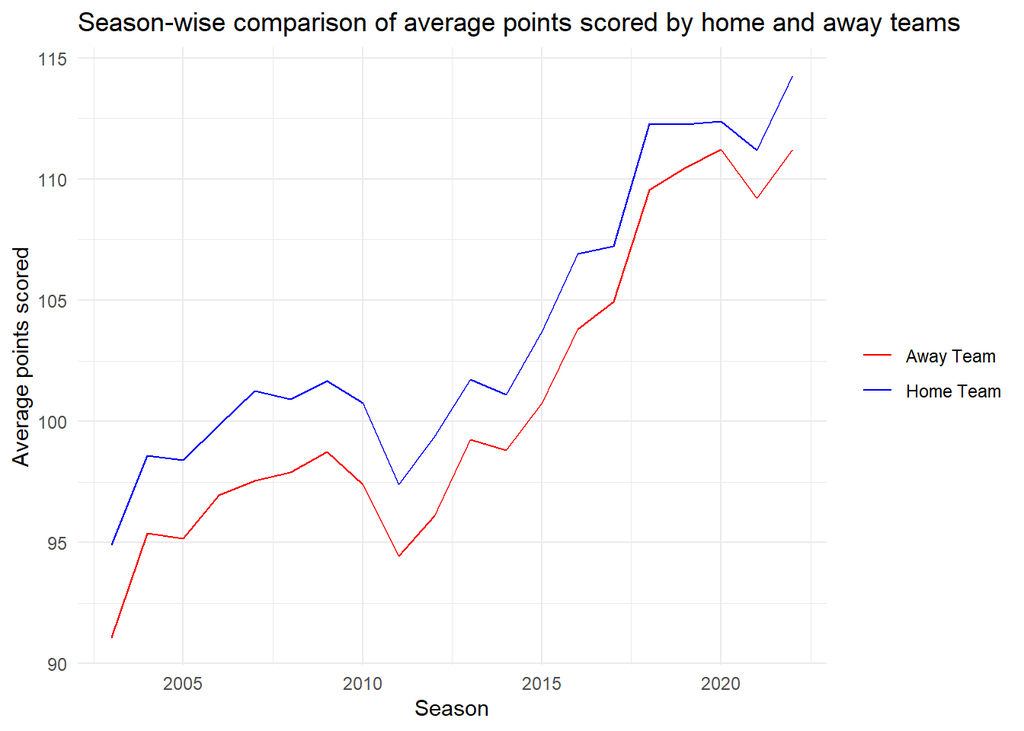

```r
library(tidyverse)

games_summary <- games %>%
  group_by(SEASON) %>%
  summarise(avg_pts_home = mean(PTS_home),
            avg_pts_away = mean(PTS_away))

ggplot(games_summary, aes(x = SEASON, y = avg_pts_home, color = "Home Team")) +
  geom_line() +
  geom_line(aes(y = avg_pts_away, color = "Away Team")) +
  scale_color_manual("", values = c("red", "blue")) +
  labs(title = "Season-wise comparison of average points scored by home and away teams",
       x = "Season",
       y = "Average points scored") +
  theme_minimal()
```

we can clearly see the home team has higher Average Points Scored over Away Team throughout all season

Top teams by games wins

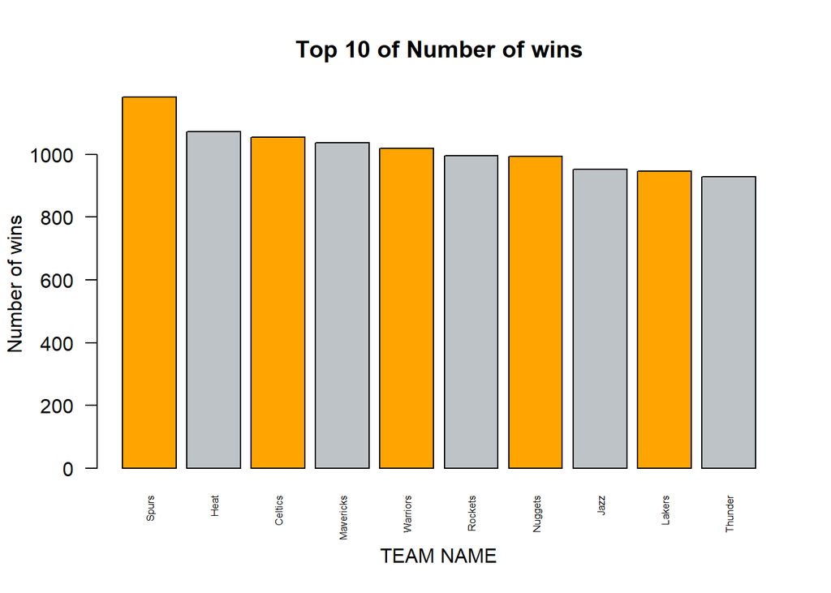

```r
plot_top <- function(df, column, label_col=NULL, max_plot=5) {
  top_df <- head(arrange(df, desc({{column}})), max_plot)

  height <- top_df[[column]]
  x <- if (is.null(label_col)) rownames(top_df) else top_df[[label_col]]

  colors <- c("#FFA400", "#bdc3c7", "#cd7f32", "#3498db")[1:length(top_df)]

  fig <- barplot(height, names.arg=x, col=colors, main=paste("Top", max_plot, "of", column), xlab=label_col, ylab=column, las=2, cex.names=0.5)

}

winning_teams <- ifelse(games$HOME_TEAM_WINS == 1, games$HOME_TEAM_ID, games$VISITOR_TEAM_ID)
winning_teams <- data.frame(TEAM_ID = winning_teams)
winning_teams <- merge(winning_teams, teams[c('TEAM_ID', 'NICKNAME')], by = 'TEAM_ID')
winning_teams <- table(winning_teams$NICKNAME)
winning_teams <- as.data.frame(winning_teams)
names(winning_teams) <- c('TEAM NAME', 'Number of wins')

winning_teams <- arrange(winning_teams, desc(`Number of wins`))

plot_top(winning_teams, column='Number of wins', label_col='TEAM NAME', max_plot=10)
```

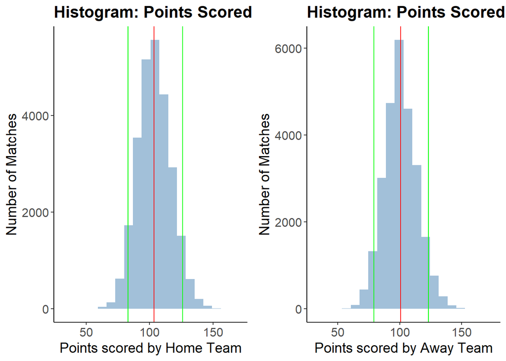

```r
library(ggplot2)
library(cowplot)

# Load data from CSV file
data2 <- games

# Create histogram with 20 bins for home team
p1 <- ggplot(data2, aes(x = PTS_home)) +
  geom_histogram(bins = 20, fill = "steelblue", alpha = 0.5) +

  # Add vertical lines for mean and 5th/95th percentiles
  geom_vline(xintercept = mean(data2$PTS_home, na.rm = TRUE), color = "red") +
  geom_vline(xintercept = quantile(data2$PTS_home, probs = 0.05), color = "green") +
  geom_vline(xintercept = quantile(data2$PTS_home, probs = 0.95), color = "green") +

  # Add labels and title
  xlab("Points scored by Home Team") +
  ylab("Number of Matches") +
  ggtitle("Histogram: Points Scored by Home Team") +

  # Adjust the appearance of the plot
  theme_classic() +
  theme(plot.title = element_text(size = 16, face = "bold"),
        axis.title = element_text(size = 14),
        axis.text = element_text(size = 12),
        panel.grid = element_blank(),
        panel.border = element_blank())

# Create histogram with 20 bins for away team
p2 <- ggplot(data2, aes(x = PTS_away)) +
  geom_histogram(bins = 20, fill = "steelblue", alpha = 0.5) +

  # Add vertical lines for mean and 5th/95th percentiles
  geom_vline(xintercept = mean(data2$PTS_away, na.rm = TRUE), color = "red") +
  geom_vline(xintercept = quantile(data2$PTS_away, probs = 0.05), color = "green") +
  geom_vline(xintercept = quantile(data2$PTS_away, probs = 0.95), color = "green") +

  # Add labels and title
  xlab("Points scored by Away Team") +
  ylab("Number of Matches") +
  ggtitle("Histogram: Points Scored by Away Team") +

  # Adjust the appearance of the plot
  theme_classic() +
  theme(plot.title = element_text(size = 16, face = "bold"),
        axis.title = element_text(size = 14),
        axis.text = element_text(size = 12),
        panel.grid = element_blank(),
        panel.border = element_blank())

# Display both histograms side by side
plot_grid(p1, p2, ncol = 2)
```

90% percentile range of Scores for both Home Team and Away Team

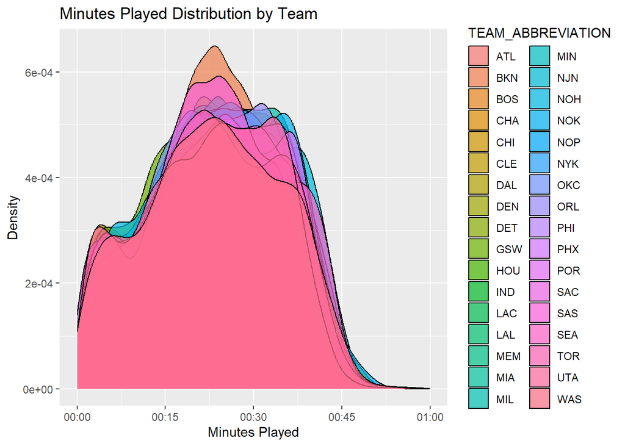

```r
# Load necessary libraries
library(ggplot2)
library(dplyr)

# Convert the MIN column from a string to a time format
games_details$MIN <- as.POSIXct(games_details$MIN, format = "%M:%S")

# Plot 1: Minutes played distribution by team
ggplot(games_details, aes(x = MIN, fill = TEAM_ABBREVIATION)) +
  geom_density(alpha = 0.7) +
  labs(title = "Minutes Played Distribution by Team", x = "Minutes Played", y = "Density")
```

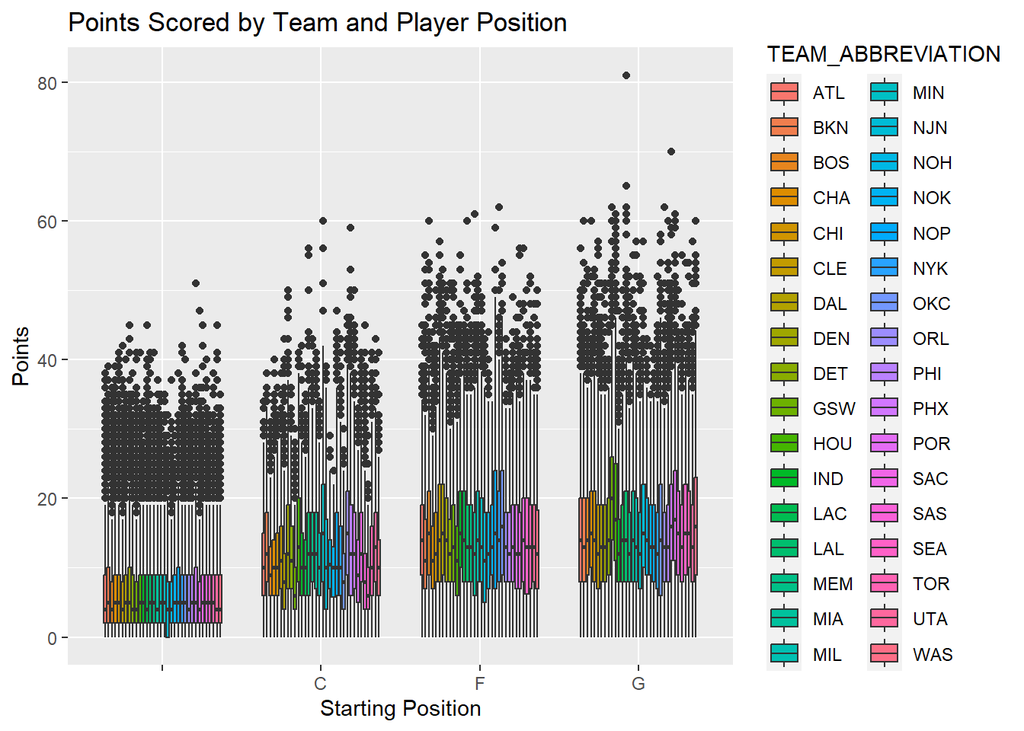

```r
# Plot 2: Points scored by team and player position
ggplot(games_details, aes(x = START_POSITION, y = PTS, fill = TEAM_ABBREVIATION)) +
  geom_boxplot() +
  labs(title = "Points Scored by Team and Player Position", x = "Starting Position", y = "Points")
```

We can see that Guard has the highest points scored across all the teams as they are the front most players and Guards are normally the shortest players on the court. They use their speed and quickness for dribbling, passing, and shooting on offense. They often guard the perimeter of the court on defense.

Top Players by games played

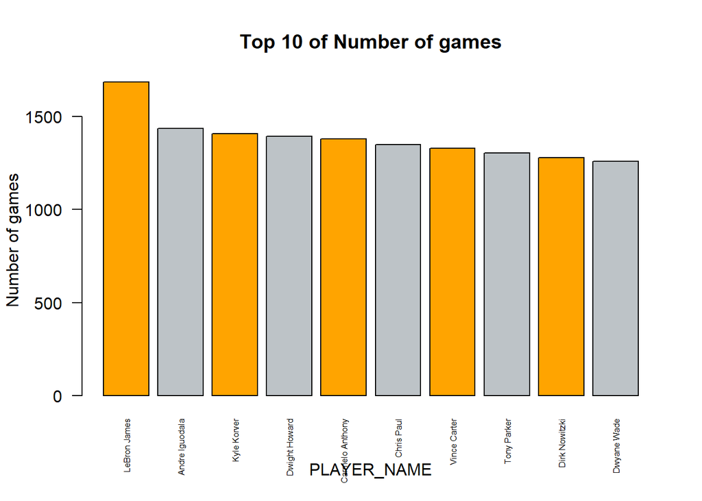

```r
library(dplyr)

players_name <- games_details$PLAYER_NAME
val_cnt <- as.data.frame(table(players_name))
colnames(val_cnt) <- c("PLAYER_NAME", "Number of games")

val_cnt <- arrange(val_cnt, desc(`Number of games`))

plot_top(val_cnt, column="Number of games", label_col="PLAYER_NAME", max_plot=10)
```

We take LeBron James for Time series Forecasting as he has played for the longest i.e. has larger past data

```r
# Load required packages
library(tidyverse)
library(lubridate)
library(tsibble)
library(forecast)
# Load games and game details datasets
games <- read.csv("games.csv")
games_details <- read.csv("games_details.csv")

# Merge datasets
games_full <- games_details %>%
  select(GAME_ID, PLAYER_ID, PTS) %>%
  inner_join(games, by = "GAME_ID")
# Filter games for LeBron James
lebron_games <- games_full %>%
  filter(PLAYER_ID == 2544)

# Convert GAME_DATE_EST to date format
lebron_games$GAME_DATE_EST <- ymd(lebron_games$GAME_DATE_EST)

# Create time series of LeBron's points per game
lebron_ts <- lebron_games %>%
  select(GAME_DATE_EST, PTS) %>%
  group_by(GAME_DATE_EST) %>%
  summarise(PTS = sum(PTS)) %>%
  as_tsibble(index = GAME_DATE_EST)



str(lebron_ts)
```

```
## tbl_ts [1,794 × 2] (S3: tbl_ts/tbl_df/tbl/data.frame)
##  $ GAME_DATE_EST: Date[1:1794], format: "2003-10-07" "2003-10-08" ...
##  $ PTS          : num [1:1794] 8 6 25 21 8 7 23 17 17 18 ...
##  - attr(*, "key")= tibble [1 × 1] (S3: tbl_df/tbl/data.frame)
##   ..$ .rows: list<int> [1:1]
##   .. ..$ : int [1:1794] 1 2 3 4 5 6 7 8 9 10 ...
##   .. ..@ ptype: int(0)
##  - attr(*, "index")= chr "GAME_DATE_EST"
##   ..- attr(*, "ordered")= logi TRUE
##  - attr(*, "index2")= chr "GAME_DATE_EST"
##  - attr(*, "interval")= interval [1:1] 1D
##   ..@ .regular: logi TRUE
```

Making Time Series Data for LeBron James

```r
# Convert the GAME_DATE_EST column to year-month format
lebron_ts$year_year <- format(lebron_ts$GAME_DATE_EST, "%Y")

# Use the aggregate function to calculate the monthly total of the PTS column
lebron_ts_yearly <- aggregate(PTS ~ year_year, data = lebron_ts, sum)

# Print the resulting monthly time series data
head(lebron_ts_yearly, 10)
```

```
##    year_year  PTS
## 1       2003  661
## 2       2004 1742
## 3       2005 2427
## 4       2006 2894
## 5       2007 2671
## 6       2008 2826
## 7       2009 2995
## 8       2010 2549
## 9       2011 1956
## 10      2012 3106
```

Converting to time series object

```r
# Convert the data into a time series object
lebron_ts <- ts(lebron_ts_yearly$PTS, start = c(2003), end = c(2022), frequency = 1)
```

# 11. ARIMA

```r
library(forecast)

# Fit an ARIMA model to the time series
arima_model <- auto.arima(lebron_ts)

# Print the model summary
summary(arima_model)
```

```
## Series: lebron_ts
## ARIMA(1,0,0) with non-zero mean
##
## Coefficients:
##          ar1       mean
##       0.5825  2188.9054
## s.e.  0.2344   300.6256
##
## sigma^2 = 334292:  log likelihood = -154.73
## AIC=315.46   AICc=316.96   BIC=318.45
##
## Training set error measures:
##                    ME     RMSE      MAE       MPE     MAPE      MASE      ACF1
## Training set 58.79885 548.5092 413.0897 -7.656733 25.29795 0.9111567 -0.110289
```

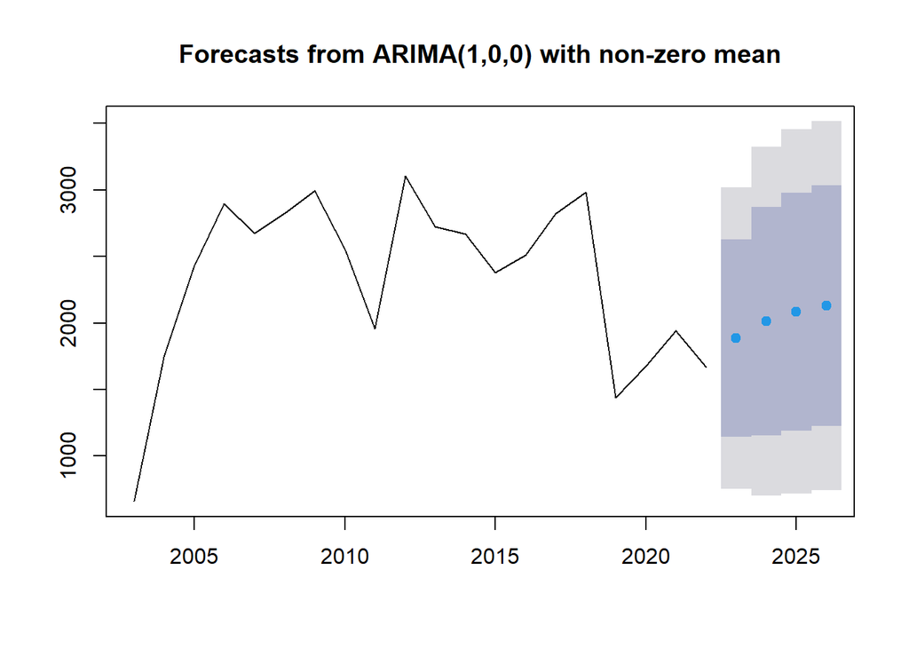

```r
#Forecast 4 steps ahead
forecast_prices <- forecast(arima_model, h = 4)

#Plot forecast
plot(forecast_prices)
```

# 12. Simple Moving Average

```r
# Calculate a 2-year moving average
library(TTR)
sma <- SMA(lebron_ts, n = 2)
# Combine the moving average and original time series as a dataframe
df <- cbind(sma, lebron_ts_yearly$PTS)

# Rename the columns
colnames(df) <- c("SMA", "PTS")

# Calculate MAPE
mape <- accuracy(sma, lebron_ts_yearly$PTS)[, "MAPE"]

# Print the dataframe and MAPE
cat("Moving Average Results:\n")
```

```
## Moving Average Results:
```

```r
print(df)
```

```
## Time Series:
## Start = 2003
## End = 2022
## Frequency = 1
##         SMA  PTS
## 2003     NA  661
## 2004 1201.5 1742
## 2005 2084.5 2427
## 2006 2660.5 2894
## 2007 2782.5 2671
## 2008 2748.5 2826
## 2009 2910.5 2995
## 2010 2772.0 2549
## 2011 2252.5 1956
## 2012 2531.0 3106
## 2013 2915.5 2725
## 2014 2696.0 2667
## 2015 2523.0 2379
## 2016 2445.0 2511
## 2017 2665.5 2820
## 2018 2900.5 2981
## 2019 2210.5 1440
## 2020 1560.0 1680
## 2021 1810.5 1941
## 2022 1804.0 1667
```

```r
cat("MAPE:", mape, "\n")
```

```
## MAPE: 10.83664
```

```r
str(df)
```

```
##  Time-Series [1:20, 1:2] from 2003 to 2022: NA 1202 2084 2660 2782 ...
##  - attr(*, "dimnames")=List of 2
##   ..$ : NULL
##   ..$ : chr [1:2] "SMA" "PTS"
```

```r
df <- as.data.frame(df)
```

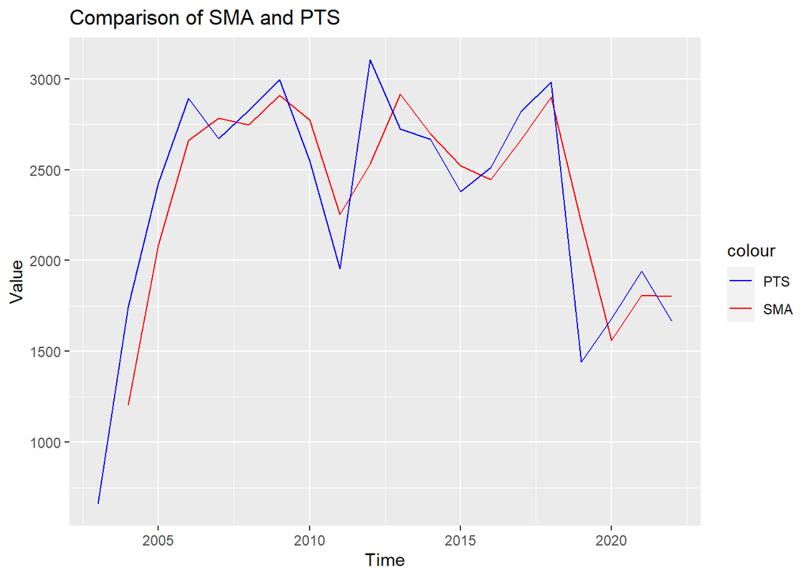

```r
library(ggplot2)

# Create a sample data frame
df <- data.frame(
  Time = seq(as.Date("2003-01-01"), as.Date("2022-01-01"), by = "year"),
  SMA = df$SMA,
  PTS = df$PTS
)

# Plot the line graph
ggplot(df, aes(Time)) +
  geom_line(aes(y = SMA, color = "SMA")) +
  geom_line(aes(y = PTS, color = "PTS")) +
  labs(title = "Comparison of SMA and PTS", x = "Time", y = "Value") +
  scale_color_manual(values = c("SMA" = "red", "PTS" = "blue"))
```

We can clearly observe that SMA is very close to the real observed PTS yearly

# 13. Exponential Smoothing

```r
library(forecast)

# Fit an Exponential Smoothing model to the time series
es_model <- ets(lebron_ts)

# Print the model summary
summary(es_model)
```

```
## ETS(A,N,N)
##
## Call:
##  ets(y = lebron_ts)
##
##   Smoothing parameters:
##     alpha = 0.8406
##
##   Initial states:
##     l = 854.0578
##
##   sigma:  609.9091
##
##      AIC     AICc      BIC
## 320.3398 321.8398 323.3270
##
## Training set error measures:
##                    ME     RMSE      MAE       MPE     MAPE      MASE       ACF1
## Training set 50.56009 578.6106 424.9545 -1.514342 21.14927 0.9373271 0.01243129
```

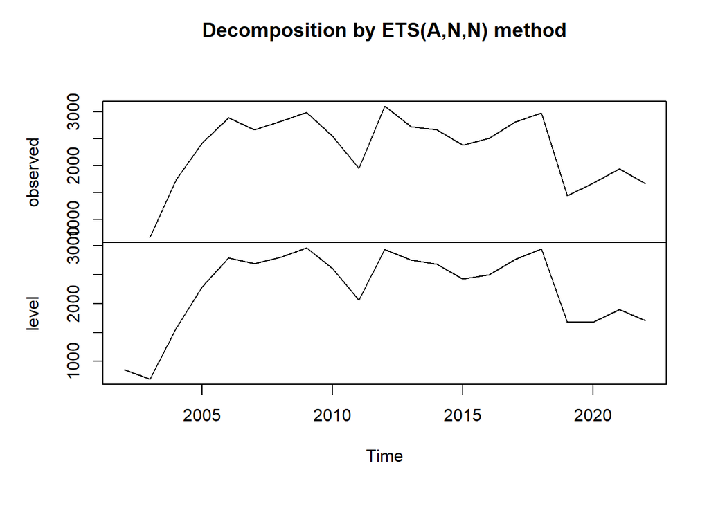

```r
plot(es_model)
```

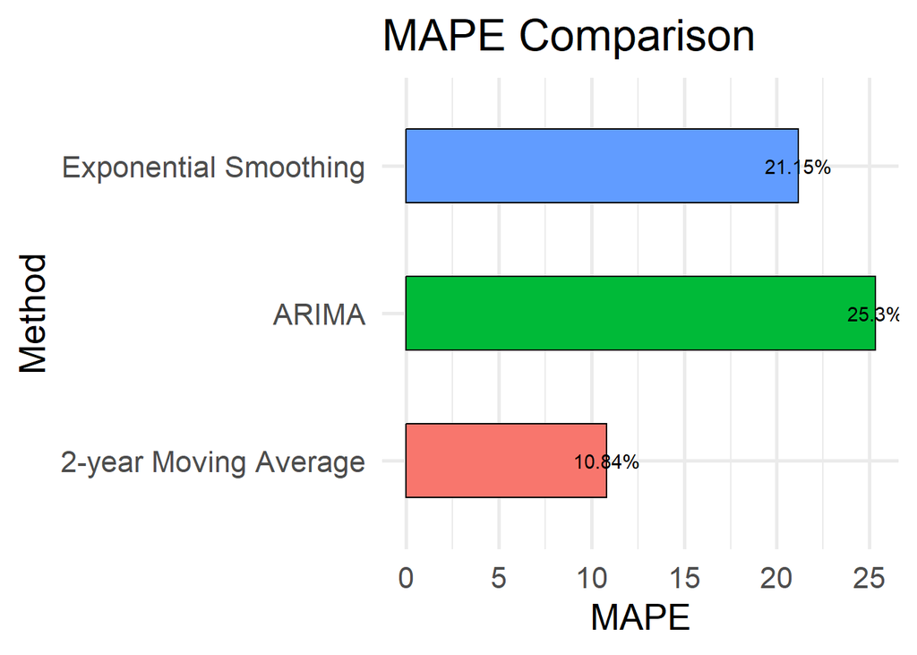

```r
library(ggplot2)

# Calculate MAPE for ARIMA model
arima_mape <- accuracy(arima_model$fitted, lebron_ts_yearly$PTS)[, "MAPE"]

# Calculate MAPE for 2-year Moving Average
mape <- accuracy(sma, lebron_ts_yearly$PTS)[, "MAPE"]

# Calculate MAPE for Exponential Smoothing model
es_mape <- accuracy(es_model$fitted, lebron_ts_yearly$PTS)[, "MAPE"]

# Create a data frame with MAPE values for each method
mape_df <- data.frame(Method = c("ARIMA", "2-year Moving Average", "Exponential Smoothing"),
                      MAPE = c(arima_mape, mape, es_mape))

# Create a bar plot of MAPE values
ggplot(mape_df, aes(x = Method, y = MAPE, fill = Method)) +
  geom_bar(stat = "identity", color = "black", width = 0.5) +
  labs(title = "MAPE Comparison",
       x = "Method",
       y = "MAPE") +
  theme_minimal(base_size = 20) +
  theme(legend.position = "none") +
  geom_text(aes(label = paste0(round(MAPE, 2), "%")), vjust = 0.5) +
  coord_flip()
```

We can clearly see that 2-year Moving Average is outperforming Exponential Smoothing and ARIMA. 2-year Moving Average has only 10.84% variance from observed points on an average per year.

```r
str(games)
```

```
## 'data.frame':    26651 obs. of  21 variables:
##  $ GAME_DATE_EST   : chr  "2022-12-22" "2022-12-22" "2022-12-21" "2022-12-21" ...
##  $ GAME_ID         : int  22200477 22200478 22200466 22200467 22200468 22200469 22200470 22200471 22200472 22200473 ...
##  $ GAME_STATUS_TEXT: chr  "Final" "Final" "Final" "Final" ...
##  $ HOME_TEAM_ID    : int  1610612740 1610612762 1610612739 1610612755 1610612737 1610612738 1610612751 1610612752 1610612745 1610612750 ...
##  $ VISITOR_TEAM_ID : int  1610612759 1610612764 1610612749 1610612765 1610612741 1610612754 1610612744 1610612761 1610612753 1610612742 ...
##  $ SEASON          : int  2022 2022 2022 2022 2022 2022 2022 2022 2022 2022 ...
##  $ TEAM_ID_home    : int  1610612740 1610612762 1610612739 1610612755 1610612737 1610612738 1610612751 1610612752 1610612745 1610612750 ...
##  $ PTS_home        : num  126 120 114 113 108 112 143 106 110 99 ...
##  $ FG_PCT_home     : num  0.484 0.488 0.482 0.441 0.429 0.386 0.643 0.553 0.466 0.494 ...
##  $ FT_PCT_home     : num  0.926 0.952 0.786 0.909 1 0.84 0.875 0.611 0.647 0.7 ...
##  $ FG3_PCT_home    : num  0.382 0.457 0.313 0.297 0.378 0.317 0.636 0.423 0.395 0.267 ...
##  $ AST_home        : num  25 16 22 27 22 26 42 25 22 23 ...
##  $ REB_home        : num  46 40 37 49 47 62 32 38 49 39 ...
##  $ TEAM_ID_away    : int  1610612759 1610612764 1610612749 1610612765 1610612741 1610612754 1610612744 1610612761 1610612753 1610612742 ...
##  $ PTS_away        : num  117 112 106 93 110 117 113 113 116 104 ...
##  $ FG_PCT_away     : num  0.478 0.561 0.47 0.392 0.5 0.469 0.494 0.447 0.451 0.453 ...
##  $ FT_PCT_away     : num  0.815 0.765 0.682 0.735 0.773 0.778 0.76 0.909 0.697 0.852 ...
##  $ FG3_PCT_away    : num  0.321 0.333 0.433 0.261 0.292 0.462 0.364 0.265 0.297 0.333 ...
##  $ AST_away        : num  23 20 20 15 20 27 32 17 19 17 ...
##  $ REB_away        : num  44 37 46 46 47 47 36 38 45 39 ...
##  $ HOME_TEAM_WINS  : int  1 1 1 1 0 0 1 0 0 0 ...
```

```r
str(games_details)
```

```
## 'data.frame':    668628 obs. of  29 variables:
##  $ GAME_ID          : int  22200477 22200477 22200477 22200477 22200477 22200477 22200477 22200477 22200477 22200477 ...
##  $ TEAM_ID          : int  1610612759 1610612759 1610612759 1610612759 1610612759 1610612759 1610612759 1610612759 1610612759 1610612759 ...
##  $ TEAM_ABBREVIATION: chr  "SAS" "SAS" "SAS" "SAS" ...
##  $ TEAM_CITY        : chr  "San Antonio" "San Antonio" "San Antonio" "San Antonio" ...
##  $ PLAYER_ID        : int  1629641 1631110 1627751 1630170 1630200 1628380 203926 1626196 1631103 1628966 ...
##  $ PLAYER_NAME      : chr  "Romeo Langford" "Jeremy Sochan" "Jakob Poeltl" "Devin Vassell" ...
##  $ NICKNAME         : chr  "Romeo" "Jeremy" "Jakob" "Devin" ...
##  $ START_POSITION   : chr  "F" "F" "C" "G" ...
##  $ COMMENT          : chr  "" "" "" "" ...
##  $ MIN              : chr  "18:06" "31:01" "21:42" "30:20" ...
##  $ FGM              : num  1 7 6 4 7 2 2 5 4 1 ...
##  $ FGA              : num  1 14 9 13 12 6 8 11 6 3 ...
##  $ FG_PCT           : num  1 0.5 0.667 0.308 0.583 0.333 0.25 0.455 0.667 0.333 ...
##  $ FG3M             : num  0 2 0 1 1 0 1 2 1 0 ...
##  $ FG3A             : num  0 4 0 6 3 0 5 5 3 0 ...
##  $ FG3_PCT          : num  0 0.5 0 0.167 0.333 0 0.2 0.4 0.333 0 ...
##  $ FTM              : num  0 7 1 1 4 2 0 2 0 2 ...
##  $ FTA              : num  0 10 1 1 4 2 0 3 0 2 ...
##  $ FT_PCT           : num  0 0.7 1 1 1 1 0 0.667 0 1 ...
##  $ OREB             : num  1 6 1 0 0 1 1 1 0 1 ...
##  $ DREB             : num  1 3 3 9 2 1 3 2 0 0 ...
##  $ REB              : num  2 9 4 9 2 2 4 3 0 1 ...
##  $ AST              : num  0 6 1 5 3 2 1 3 0 0 ...
##  $ STL              : num  1 1 1 3 0 0 0 0 0 0 ...
##  $ BLK              : num  0 0 0 0 0 0 0 0 0 0 ...
##  $ TO               : num  2 2 2 2 2 0 1 1 1 0 ...
##  $ PF               : num  5 1 4 1 2 3 0 2 2 1 ...
##  $ PTS              : num  2 23 13 10 19 6 5 14 9 4 ...
##  $ PLUS_MINUS       : num  -2 -14 -4 -18 0 -13 -10 -2 -6 -1 ...
```

```r
str(teams)
```

```
## 'data.frame':    26 obs. of  14 variables:
##  $ LEAGUE_ID         : int  0 0 0 0 0 0 0 0 0 0 ...
##  $ TEAM_ID           : int  1610612737 1610612738 1610612741 1610612742 1610612743 1610612745 1610612746 1610612747 1610612748 1610612749 ...
##  $ MIN_YEAR          : int  1949 1946 1966 1980 1976 1967 1970 1948 1988 1968 ...
##  $ MAX_YEAR          : int  2019 2019 2019 2019 2019 2019 2019 2019 2019 2019 ...
##  $ ABBREVIATION      : chr  "ATL" "BOS" "CHI" "DAL" ...
##  $ NICKNAME          : chr  "Hawks" "Celtics" "Bulls" "Mavericks" ...
##  $ YEARFOUNDED       : int  1949 1946 1966 1980 1976 1967 1970 1948 1988 1968 ...
##  $ CITY              : chr  "Atlanta" "Boston" "Chicago" "Dallas" ...
##  $ ARENA             : chr  "State Farm Arena" "TD Garden" "United Center" "American Airlines Center" ...
##  $ ARENACAPACITY     : int  18729 18624 21711 19200 19099 18104 19060 19060 19600 17500 ...
##  $ OWNER             : chr  "Tony Ressler" "Wyc Grousbeck" "Jerry Reinsdorf" "Mark Cuban" ...
##  $ GENERALMANAGER    : chr  "Travis Schlenk" "Danny Ainge" "Gar Forman" "Donnie Nelson" ...
##  $ HEADCOACH         : chr  "Lloyd Pierce" "Brad Stevens" "Jim Boylen" "Rick Carlisle" ...
##  $ DLEAGUEAFFILIATION: chr  "Erie Bayhawks" "Maine Red Claws" "Windy City Bulls" "Texas Legends" ...
```